# Exploratory Analyses Lexical Transparency

Katie Von Holzen

2023-06-16

# Participants

In this analysis, children with >50% accuracy on non-cognate words in English CLT are excluded in the analysis.

| 1st grade/class | 2nd grade/class | keep |
| --- | --- | --- |
| 48 | 40 | Current Keepers |
| 6 | 11 | Children with >50% accuracy on non-cognate words in English CLT |
| NA | 7 | English CLT still needs to be coded |
| 3 | 9 | No questionnaire data |
| 2 | NA | Child has reported hearing problems |
| 1 | NA | Child has SLD |
| NA | 1 | Child has ADHD |
| 1 | NA | Child is suspected to have autism |
| 3 | NA | Child did not want to continue |
| 1 | NA | not enough trials per condition |
| 2 | NA | Questionnaire was started but not completed |

# Recognition: Cognate vs. Non-cognate words

## Main Analysis

### Cognate Status by Word Status

```
## Generalized linear mixed model fit by maximum likelihood (Laplace
##   Approximation) [glmerMod]
##  Family: binomial  ( logit )
## Formula: detection ~ 1 + Word_Type * Word_Status + (1 | subject_nr) +
##     (1 | Sentence_Num)
##    Data: Lseg_Htest
## Control: glmerControl(optimizer = "bobyqa")
##
##      AIC      BIC   logLik deviance df.resid
##  10327.2  10370.4  -5157.6  10315.2     9934
##
## Scaled residuals:
##     Min      1Q  Median      3Q     Max
## -2.3192 -0.6227 -0.3569  0.7709  5.7957
##
## Random effects:
##  Groups       Name        Variance Std.Dev.
##  Sentence_Num (Intercept) 0.03509  0.1873
##  subject_nr   (Intercept) 1.46764  1.2115
## Number of obs: 9940, groups:  Sentence_Num, 160; subject_nr, 88
##
## Fixed effects:
##                          Estimate Std. Error z value Pr(>|z|)
## (Intercept)             -0.896138   0.133152  -6.730 1.69e-11 ***
## Word_Type1              -0.035044   0.050249  -0.697    0.486
## Word_Status1             1.062822   0.051020  20.832  < 2e-16 ***
## Word_Type1:Word_Status1  0.007196   0.100499   0.072    0.943
## ---
## Signif. codes:  0 '***' 0.001 '**' 0.01 '*' 0.05 '.' 0.1 ' ' 1
##
## Correlation of Fixed Effects:
##             (Intr) Wrd_T1 Wrd_S1
## Word_Type1   0.001
## Word_Stats1  0.031 -0.002
## Wrd_T1:W_S1  0.000  0.225  0.000
```

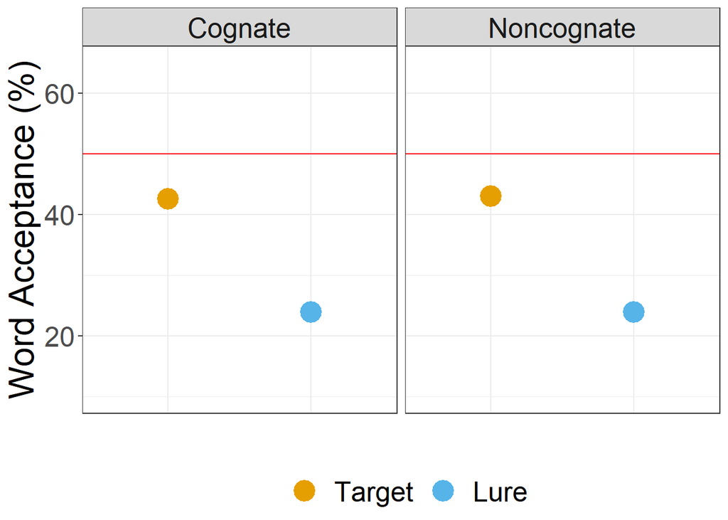

### Individual Differences with Cognate Status by Word Status

Model below is built using buildmer, mostly only for fixed effects for now

```r
# f <- detection ~ Word_Status*Word_Type +
#   RAVENS_IQ.c + WM_BackDigitSpan.c + Ger_CLT_Prod.c + NWRT_total_correct.c + Phoneme_Manipulation.c + Onset_Rhyme.c + ENG_CLT_score.c +
#   (1+Word_Status*Word_Type | subject_nr) +
#   (1+Word_Status*Word_Type | Sentence_Num)
#
# model_1 <- buildmer(f,
#                     family=binomial,
#                     data=Lseg_Htest,
#               buildmerControl=buildmerControl(direction=c('order', "backward")))
#
# model_1 <- model_1@model
#
# model_1_formula <- model_1@call
#
# summary(model_1)
```

Generalized linear mixed model fit by maximum likelihood (Laplace Approximation) [‘glmerMod’] Family: binomial ( logit ) Formula: detection ~ 1 + Word_Status + (1 + Word_Status | subject_nr) + (1 + Word_Status | Sentence_Num) Data: Lseg_Htest

```
 AIC      BIC   logLik deviance df.resid
```

10117.3 10174.9 -5050.6 10101.3 9932

Scaled residuals: Min 1Q Median 3Q Max -2.0333 -0.6041 -0.3141 0.7600 6.3618

Correlation of Fixed Effects: (Intr) Word_Stats1 -0.336

### Role of Phonological Awareness, with control variables Ravens IQ, Working Memory, and German CLT

```
## Generalized linear mixed model fit by maximum likelihood (Laplace
##   Approximation) [glmerMod]
##  Family: binomial  ( logit )
## Formula: detection ~ 1 + Word_Type * Word_Status * Phoneme_Manipulation.c +
##     RAVENS_IQ + Ger_CLT_Prod.c + WM_BackDigitSpan.c + (1 | subject_nr) +
##     (1 | Sentence_Num)
##    Data: Lseg_Htest
## Control: glmerControl(optimizer = "bobyqa")
##
##      AIC      BIC   logLik deviance df.resid
##   9968.7  10061.8  -4971.4   9942.7     9466
##
## Scaled residuals:
##     Min      1Q  Median      3Q     Max
## -2.2400 -0.6366 -0.3524  0.7977  5.8656
##
## Random effects:
##  Groups       Name        Variance Std.Dev.
##  Sentence_Num (Intercept) 0.04121  0.203
##  subject_nr   (Intercept) 1.23848  1.113
## Number of obs: 9479, groups:  Sentence_Num, 160; subject_nr, 84
##
## Fixed effects:
##                                                 Estimate Std. Error z value
## (Intercept)                                     1.828419   1.109744   1.648
## Word_Type1                                     -0.034509   0.051221  -0.674
## Word_Status1                                    1.048195   0.051924  20.187
## Phoneme_Manipulation.c                          0.025563   0.041297   0.619
## RAVENS_IQ                                      -0.026544   0.010926  -2.429
## Ger_CLT_Prod.c                                 -0.145229   0.064007  -2.269
## WM_BackDigitSpan.c                             -0.145039   0.164306  -0.883
## Word_Type1:Word_Status1                         0.014473   0.102439   0.141
## Word_Type1:Phoneme_Manipulation.c              -0.022077   0.014956  -1.476
## Word_Status1:Phoneme_Manipulation.c             0.074854   0.015195   4.926
## Word_Type1:Word_Status1:Phoneme_Manipulation.c -0.005554   0.029919  -0.186
##                                                Pr(>|z|)
## (Intercept)                                      0.0994 .
## Word_Type1                                       0.5005
## Word_Status1                                    < 2e-16 ***
## Phoneme_Manipulation.c                           0.5359
```

[output cut: 22 more lines]

```
##             W_S1:P
## Word_Type1
## Word_Stats1
## Phnm_Mnplt.
## RAVENS_IQ
## Gr_CLT_Prd.
## WM_BckDgtS.
## Wrd_T1:W_S1
## Wrd_T1:P_M.
## Wrd_S1:P_M.
## W_T1:W_S1:P  0.013
## optimizer (bobyqa) convergence code: 1 (bobyqa -- maximum number of function evaluations exceeded)
## Model failed to converge with max|grad| = 0.0472149 (tol = 0.002, component 1)
## Model is nearly unidentifiable: very large eigenvalue
##  - Rescale variables?
```

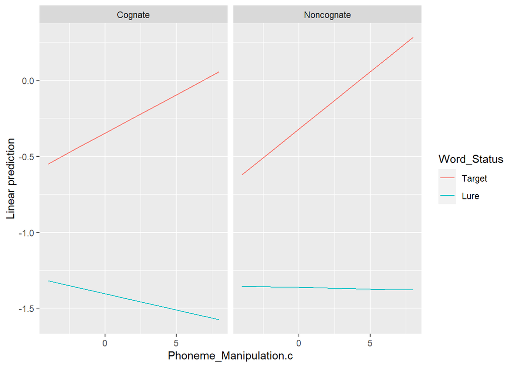

### *d’* analyses

```
## Linear mixed model fit by REML. t-tests use Satterthwaite's method [
## lmerModLmerTest]
## Formula: dprime ~ 1 + Word_Type + Phoneme_Manipulation.c + RAVENS_IQ +
##     Ger_CLT_Prod.c + WM_BackDigitSpan.c + (1 | subject_nr)
##    Data: d_calc
##
## REML criterion at convergence: 302.2
##
## Scaled residuals:
##      Min       1Q   Median       3Q      Max
## -1.94361 -0.53598 -0.01963  0.52970  2.10026
##
## Random effects:
##  Groups     Name        Variance Std.Dev.
##  subject_nr (Intercept) 0.2000   0.4472
##  Residual               0.1643   0.4053
## Number of obs: 168, groups:  subject_nr, 84
##
## Fixed effects:
##                         Estimate Std. Error        df t value Pr(>|t|)
## (Intercept)            -0.113089   0.509562 79.000001  -0.222  0.82494
## Word_Type1             -0.010236   0.062536 83.000000  -0.164  0.87038
## Phoneme_Manipulation.c  0.014839   0.019193 79.000000   0.773  0.44172
## RAVENS_IQ               0.007241   0.005011 79.000001   1.445  0.15240
## Ger_CLT_Prod.c         -0.003508   0.029677 79.000000  -0.118  0.90621
## WM_BackDigitSpan.c      0.203228   0.075800 79.000000   2.681  0.00893 **
## ---
## Signif. codes:  0 '***' 0.001 '**' 0.01 '*' 0.05 '.' 0.1 ' ' 1
##
## Correlation of Fixed Effects:
##             (Intr) Wrd_T1 Phn_M. RAVENS G_CLT_
## Word_Type1   0.000
## Phnm_Mnplt.  0.144  0.000
## RAVENS_IQ   -0.994  0.000 -0.144
## Gr_CLT_Prd. -0.067  0.000 -0.056  0.068
## WM_BckDgtS.  0.043  0.000 -0.382 -0.045 -0.299
```

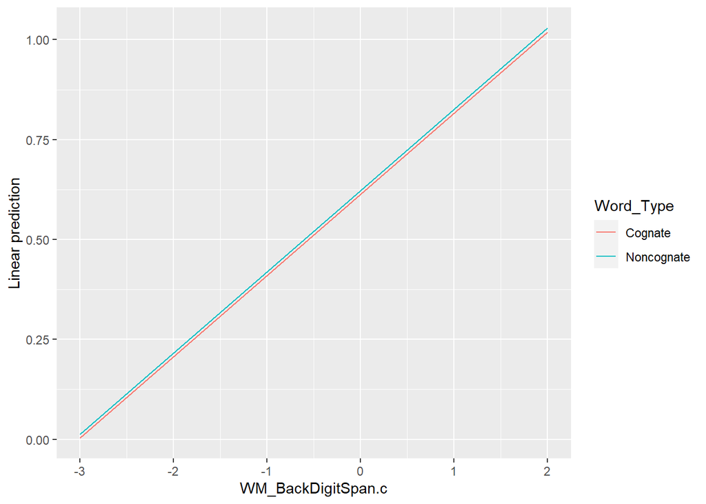

## Experiment Task Variables

### Trial

```
## Generalized linear mixed model fit by maximum likelihood (Laplace
##   Approximation) [glmerMod]
##  Family: binomial  ( logit )
## Formula:
## detection ~ 1 + Word_Type * Word_Status * Trial.c + (1 | subject_nr) +
##     (1 | Sentence_Num)
##    Data: Lseg_Htest
## Control: glmerControl(optimizer = "bobyqa")
##
##      AIC      BIC   logLik deviance df.resid
##  10329.1  10401.1  -5154.5  10309.1     9930
##
## Scaled residuals:
##     Min      1Q  Median      3Q     Max
## -2.4107 -0.6220 -0.3566  0.7704  6.1317
##
## Random effects:
##  Groups       Name        Variance Std.Dev.
##  Sentence_Num (Intercept) 0.03511  0.1874
##  subject_nr   (Intercept) 1.46894  1.2120
## Number of obs: 9940, groups:  Sentence_Num, 160; subject_nr, 88
##
## Fixed effects:
##                                   Estimate Std. Error z value Pr(>|z|)
## (Intercept)                     -0.8967235  0.1332218  -6.731 1.68e-11 ***
## Word_Type1                      -0.0342483  0.0502805  -0.681   0.4958
## Word_Status1                     1.0623772  0.0510509  20.810  < 2e-16 ***
## Trial.c                         -0.0002858  0.0005470  -0.523   0.6013
## Word_Type1:Word_Status1          0.0081480  0.1005630   0.081   0.9354
## Word_Type1:Trial.c               0.0006620  0.0010953   0.604   0.5456
## Word_Status1:Trial.c            -0.0025968  0.0010938  -2.374   0.0176 *
## Word_Type1:Word_Status1:Trial.c -0.0005755  0.0021912  -0.263   0.7928
## ---
## Signif. codes:  0 '***' 0.001 '**' 0.01 '*' 0.05 '.' 0.1 ' ' 1
##
## Correlation of Fixed Effects:
##             (Intr) Wrd_T1 Wrd_S1 Tril.c Wr_T1:W_S1 W_T1:T W_S1:T
## Word_Type1   0.001
## Word_Stats1  0.031 -0.002
## Trial.c      0.000 -0.003  0.014
## Wrd_T1:W_S1  0.000  0.226  0.000 -0.006
## Wrd_Typ1:T. -0.002 -0.001 -0.005  0.004  0.016
## Wrd_Stt1:T.  0.003 -0.006 -0.002  0.239 -0.003      0.001
## W_T1:W_S1:T -0.002  0.016 -0.003  0.001  0.000      0.238  0.004
## optimizer (bobyqa) convergence code: 0 (OK)
## Model is nearly unidentifiable: very large eigenvalue
##  - Rescale variables?
```

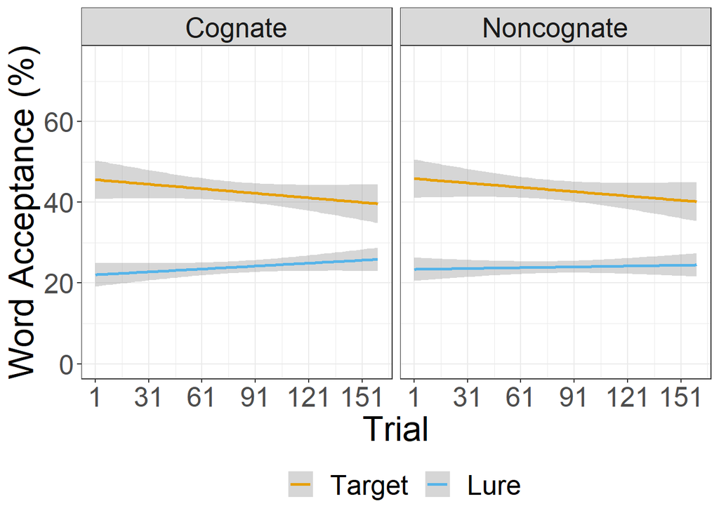

### Counterbalance List

```
## # A tibble: 8 × 2
##   List  total_participants
##   <fct>              <int>
## 1 A                     13
## 2 B                     10
## 3 C                     12
## 4 D                      6
## 5 E                     13
## 6 F                     14
## 7 G                     10
## 8 H                     10
```

```
## Generalized linear mixed model fit by maximum likelihood (Laplace
##   Approximation) [glmerMod]
##  Family: binomial  ( logit )
## Formula: detection ~ 1 + Word_Type * Word_Status * List + (1 | subject_nr) +
##     (1 | Sentence_Num)
##    Data: Lseg_Htest
## Control: glmerControl(optimizer = "bobyqa")
##
##      AIC      BIC   logLik deviance df.resid
##  10332.3  10577.3  -5132.2  10264.3     9906
##
## Scaled residuals:
##     Min      1Q  Median      3Q     Max
## -3.0936 -0.6201 -0.3563  0.7640  6.3663
##
## Random effects:
##  Groups       Name        Variance Std.Dev.
##  Sentence_Num (Intercept) 0.03534  0.188
##  subject_nr   (Intercept) 1.33091  1.154
## Number of obs: 9940, groups:  Sentence_Num, 160; subject_nr, 88
##
## Fixed effects:
##                               Estimate Std. Error z value Pr(>|z|)
## (Intercept)                   -1.02113    0.32853  -3.108 0.001882 **
## Word_Type1                    -0.28790    0.13735  -2.096 0.036076 *
## Word_Status1                   0.86801    0.13922   6.235 4.53e-10 ***
## ListB                         -0.50339    0.49912  -1.009 0.313192
## ListC                          0.70076    0.47403   1.478 0.139328
## ListD                          0.65984    0.58049   1.137 0.255664
## ListE                          0.33346    0.46340   0.720 0.471773
## ListF                         -0.22551    0.45625  -0.494 0.621123
## ListG                          0.34421    0.49636   0.693 0.488012
## ListH                         -0.10970    0.49926  -0.220 0.826089
## Word_Type1:Word_Status1       -0.34086    0.27397  -1.244 0.213446
## Word_Type1:ListB               0.14843    0.21708   0.684 0.494138
## Word_Type1:ListC               0.21917    0.19503   1.124 0.261109
## Word_Type1:ListD               0.52241    0.22773   2.294 0.021789 *
## Word_Type1:ListE               0.45424    0.19366   2.346 0.018997 *
## Word_Type1:ListF               0.40482    0.19371   2.090 0.036631 *
## Word_Type1:ListG               0.20740    0.20140   1.030 0.303110
## Word_Type1:ListH               0.07709    0.20743   0.372 0.710166
## Word_Status1:ListB             0.13256    0.22012   0.602 0.547011
## Word_Status1:ListC             0.09327    0.20189   0.462 0.644112
## Word_Status1:ListD             0.50370    0.23036   2.187 0.028778 *
## Word_Status1:ListE             0.67548    0.18886   3.577 0.000348 ***
## Word_Status1:ListF             0.03849    0.19625   0.196 0.844512
## Word_Status1:ListG             0.21772    0.20840   1.045 0.296158
## Word_Status1:ListH            -0.08432    0.20967  -0.402 0.687580
## Word_Type1:Word_Status1:ListB  0.14776    0.43330   0.341 0.733099
## Word_Type1:Word_Status1:ListC  0.31916    0.38945   0.820 0.412493
## Word_Type1:Word_Status1:ListD  0.30344    0.45472   0.667 0.504571
## Word_Type1:Word_Status1:ListE  0.94946    0.38671   2.455 0.014080 *
## Word_Type1:Word_Status1:ListF  0.75954    0.38689   1.963 0.049623 *
## Word_Type1:Word_Status1:ListG  0.11277    0.40194   0.281 0.779045
## Word_Type1:Word_Status1:ListH -0.08651    0.41404  -0.209 0.834501
## ---
## Signif. codes:  0 '***' 0.001 '**' 0.01 '*' 0.05 '.' 0.1 ' ' 1
## optimizer (bobyqa) convergence code: 0 (OK)
## maxfun < 10 * length(par)^2 is not recommended.
```

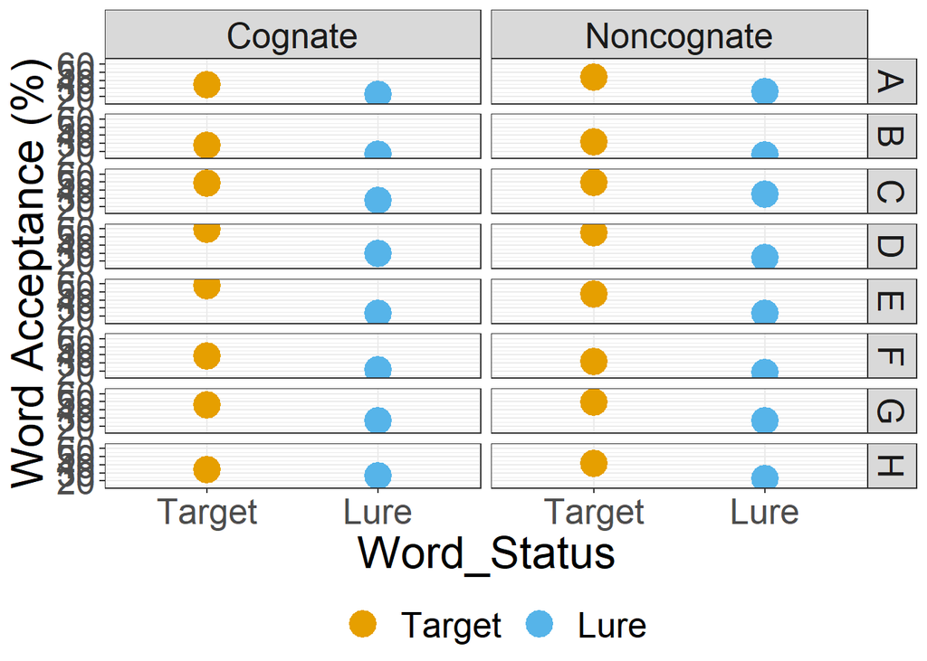

### Position in Sentence

```
## Generalized linear mixed model fit by maximum likelihood (Laplace
##   Approximation) [glmerMod]
##  Family: binomial  ( logit )
## Formula: detection ~ 1 + Word_Type * Word_Status * target_position + (1 |
##     subject_nr) + (1 | Sentence_Num)
##    Data: Lseg_Htest
## Control: glmerControl(optimizer = "bobyqa")
##
##      AIC      BIC   logLik deviance df.resid
##    10334    10406    -5157    10314     9930
##
## Scaled residuals:
##     Min      1Q  Median      3Q     Max
## -2.3634 -0.6228 -0.3562  0.7711  5.7823
##
## Random effects:
##  Groups       Name        Variance Std.Dev.
##  Sentence_Num (Intercept) 0.03478  0.1865
##  subject_nr   (Intercept) 1.46794  1.2116
## Number of obs: 9940, groups:  Sentence_Num, 160; subject_nr, 88
##
## Fixed effects:
##                                           Estimate Std. Error z value Pr(>|z|)
## (Intercept)                              -0.896378   0.133168  -6.731 1.68e-11
## Word_Type1                               -0.034984   0.050257  -0.696    0.486
## Word_Status1                              1.062534   0.051029  20.822  < 2e-16
## target_position1                          0.044182   0.058273   0.758    0.448
## Word_Type1:Word_Status1                   0.007207   0.100515   0.072    0.943
## Word_Type1:target_position1               0.047621   0.100601   0.473    0.636
## Word_Status1:target_position1             0.081159   0.100601   0.807    0.420
## Word_Type1:Word_Status1:target_position1  0.041758   0.201135   0.208    0.836
##
## (Intercept)                              ***
## Word_Type1
## Word_Status1                             ***
## target_position1
## Word_Type1:Word_Status1
## Word_Type1:target_position1
## Word_Status1:target_position1
## Word_Type1:Word_Status1:target_position1
## ---
## Signif. codes:  0 '***' 0.001 '**' 0.01 '*' 0.05 '.' 0.1 ' ' 1
##
## Correlation of Fixed Effects:
##             (Intr) Wrd_T1 Wrd_S1 trgt_1 Wr_T1:W_S1 W_T1:_ W_S1:_
## Word_Type1   0.001
## Word_Stats1  0.031 -0.002
## targt_pstn1 -0.002  0.000 -0.007
## Wrd_T1:W_S1  0.000  0.226  0.000  0.007
## Wrd_Typ1:_1  0.000 -0.008  0.007  0.002 -0.009
## Wrd_Stt1:_1 -0.003  0.007 -0.005  0.197  0.000      0.000
## W_T1:W_S1:_  0.001 -0.009  0.001 -0.001 -0.008      0.225  0.000
```

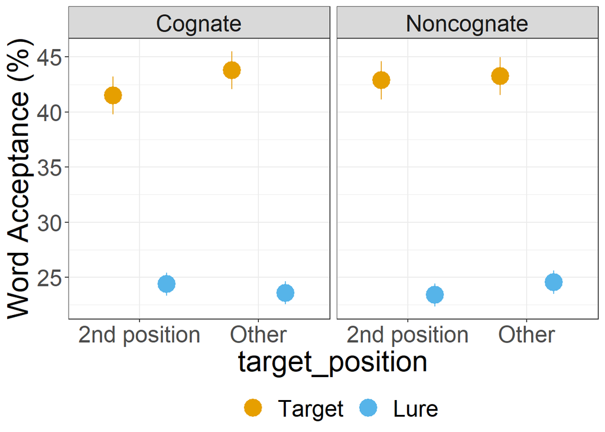

### Word Length (monosyllabic, bisyllabic)

```
## Generalized linear mixed model fit by maximum likelihood (Laplace
##   Approximation) [glmerMod]
##  Family: binomial  ( logit )
## Formula:
## detection ~ 1 + Word_Type * Word_Status * Syllable + (1 | subject_nr) +
##     (1 | Sentence_Num)
##    Data: Lseg_Htest
## Control: glmerControl(optimizer = "bobyqa")
##
##      AIC      BIC   logLik deviance df.resid
##  10327.3  10399.3  -5153.6  10307.3     9930
##
## Scaled residuals:
##     Min      1Q  Median      3Q     Max
## -2.3986 -0.6204 -0.3541  0.7690  5.9544
##
## Random effects:
##  Groups       Name        Variance Std.Dev.
##  Sentence_Num (Intercept) 0.03453  0.1858
##  subject_nr   (Intercept) 1.46919  1.2121
## Number of obs: 9940, groups:  Sentence_Num, 160; subject_nr, 88
##
## Fixed effects:
##                                    Estimate Std. Error z value Pr(>|z|)
## (Intercept)                       -0.896606   0.133207  -6.731 1.69e-11 ***
## Word_Type1                        -0.034498   0.050276  -0.686   0.4926
## Word_Status1                       1.064404   0.051047  20.852  < 2e-16 ***
## Syllable1                         -0.060545   0.058223  -1.040   0.2984
## Word_Type1:Word_Status1            0.004493   0.100554   0.045   0.9644
## Word_Type1:Syllable1               0.231923   0.100571   2.306   0.0211 *
## Word_Status1:Syllable1            -0.020674   0.100550  -0.206   0.8371
## Word_Type1:Word_Status1:Syllable1 -0.141480   0.201109  -0.703   0.4817
## ---
## Signif. codes:  0 '***' 0.001 '**' 0.01 '*' 0.05 '.' 0.1 ' ' 1
##
## Correlation of Fixed Effects:
##             (Intr) Wrd_T1 Wrd_S1 Syllb1 Wr_T1:W_S1 W_T1:S W_S1:S
## Word_Type1   0.001
## Word_Stats1  0.031 -0.001
## Syllable1    0.001 -0.007 -0.009
## Wrd_T1:W_S1  0.000  0.225  0.000  0.011
## Wrd_Typ1:S1 -0.003  0.001  0.016  0.001 -0.009
## Wrd_Stt1:S1 -0.001  0.013  0.000  0.195 -0.008      0.000
## W_T1:W_S1:S  0.003 -0.009 -0.009 -0.001  0.001      0.225 -0.001
```

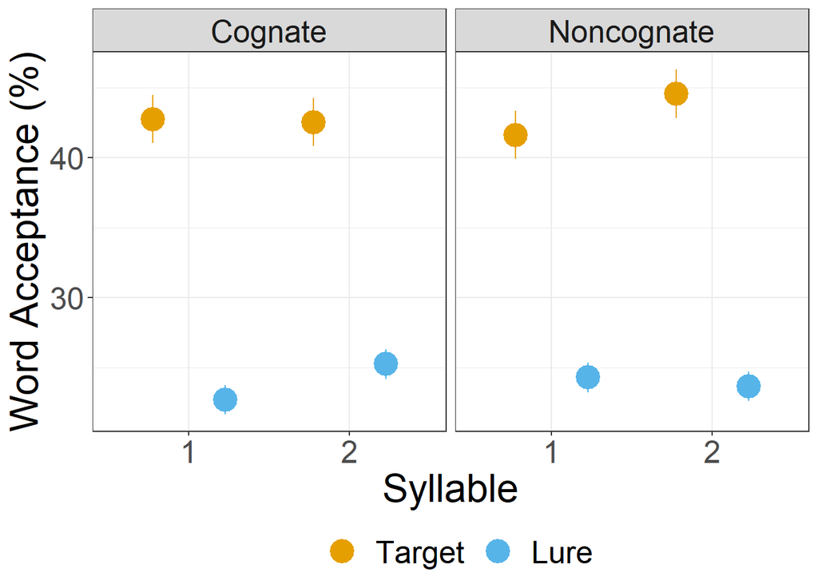

### ALINE Score

Here, ALINE score is based on the Probe word.

```
## Generalized linear mixed model fit by maximum likelihood (Laplace
##   Approximation) [glmerMod]
##  Family: binomial  ( logit )
## Formula: detection ~ 1 + Word_Status * ALINE + (1 | subject_nr) + (1 |
##     Sentence_Num)
##    Data: Lseg_Htest
## Control: glmerControl(optimizer = "bobyqa")
##
##      AIC      BIC   logLik deviance df.resid
##  10327.2  10370.5  -5157.6  10315.2     9934
##
## Scaled residuals:
##     Min      1Q  Median      3Q     Max
## -2.3258 -0.6228 -0.3565  0.7690  5.8223
##
## Random effects:
##  Groups       Name        Variance Std.Dev.
##  Sentence_Num (Intercept) 0.03521  0.1876
##  subject_nr   (Intercept) 1.46788  1.2116
## Number of obs: 9940, groups:  Sentence_Num, 160; subject_nr, 88
##
## Fixed effects:
##                    Estimate Std. Error z value Pr(>|z|)
## (Intercept)        -0.91253    0.13958  -6.538 6.24e-11 ***
## Word_Status1        1.10511    0.09787  11.292  < 2e-16 ***
## ALINE               0.04038    0.10256   0.394    0.694
## Word_Status1:ALINE -0.10426    0.20495  -0.509    0.611
## ---
## Signif. codes:  0 '***' 0.001 '**' 0.01 '*' 0.05 '.' 0.1 ' ' 1
##
## Correlation of Fixed Effects:
##             (Intr) Wrd_S1 ALINE
## Word_Stats1  0.071
## ALINE       -0.300 -0.186
## Wr_S1:ALINE -0.064 -0.853  0.215
```

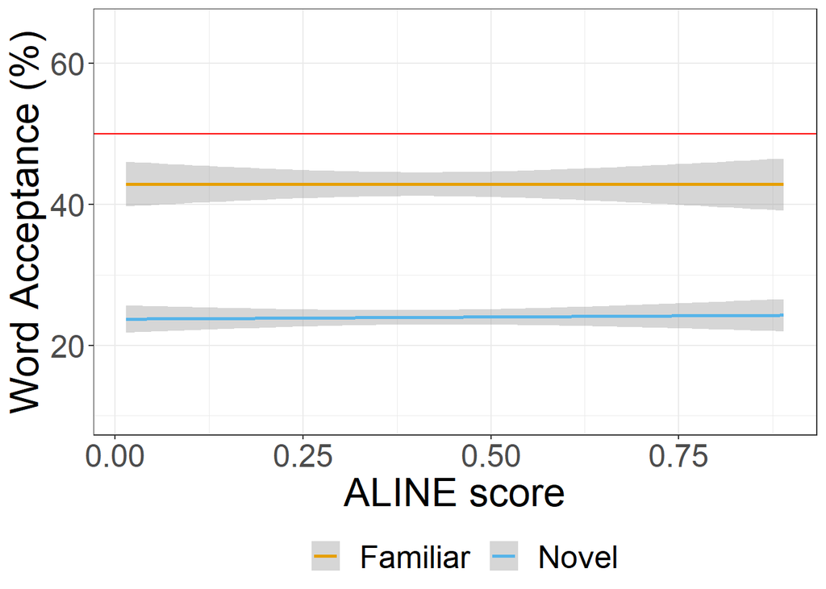

## Participant Variables: Predictors

### Correlation Individual Differences

Take with a grain of salt, these scores are the “grob” ones coded during the experiment and for some participants there are missing values (for unsure codes), but this should be fairly close to what the final coded values will be.

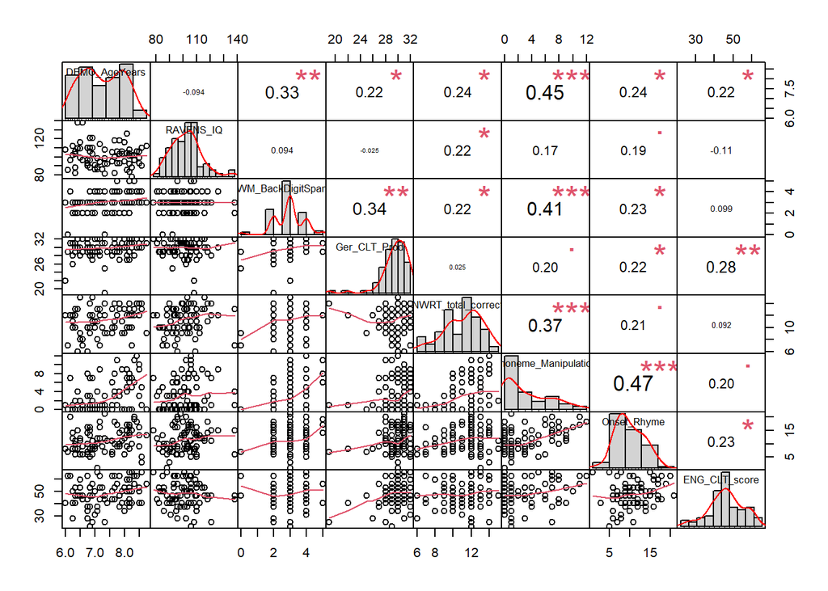

### Phonological Awareness

#### Phoneme Manipulation task score

```
## Generalized linear mixed model fit by maximum likelihood (Laplace
##   Approximation) [glmerMod]
##  Family: binomial  ( logit )
## Formula: detection ~ 1 + Word_Type * Word_Status * Phoneme_Manipulation.c +
##     (1 | subject_nr) + (1 | Sentence_Num)
##    Data: Lseg_Htest
## Control: glmerControl(optimizer = "bobyqa")
##
##      AIC      BIC   logLik deviance df.resid
##  10239.8  10311.7  -5109.9  10219.8     9815
##
## Scaled residuals:
##     Min      1Q  Median      3Q     Max
## -2.2448 -0.6261 -0.3426  0.7842  5.6066
##
## Random effects:
##  Groups       Name        Variance Std.Dev.
##  Sentence_Num (Intercept) 0.03797  0.1949
##  subject_nr   (Intercept) 1.42745  1.1948
## Number of obs: 9825, groups:  Sentence_Num, 160; subject_nr, 87
##
## Fixed effects:
##                                                 Estimate Std. Error z value
## (Intercept)                                    -0.883652   0.132230  -6.683
## Word_Type1                                     -0.031303   0.050519  -0.620
## Word_Status1                                    1.062843   0.051247  20.740
## Phoneme_Manipulation.c                         -0.020927   0.039243  -0.533
## Word_Type1:Word_Status1                         0.018887   0.101042   0.187
## Word_Type1:Phoneme_Manipulation.c              -0.020523   0.014904  -1.377
## Word_Status1:Phoneme_Manipulation.c             0.080974   0.015160   5.341
## Word_Type1:Word_Status1:Phoneme_Manipulation.c -0.006331   0.029813  -0.212
##                                                Pr(>|z|)
## (Intercept)                                    2.35e-11 ***
## Word_Type1                                        0.536
## Word_Status1                                    < 2e-16 ***
## Phoneme_Manipulation.c                            0.594
## Word_Type1:Word_Status1                           0.852
## Word_Type1:Phoneme_Manipulation.c                 0.169
## Word_Status1:Phoneme_Manipulation.c            9.24e-08 ***
## Word_Type1:Word_Status1:Phoneme_Manipulation.c    0.832
## ---
## Signif. codes:  0 '***' 0.001 '**' 0.01 '*' 0.05 '.' 0.1 ' ' 1
##
## Correlation of Fixed Effects:
##             (Intr) Wrd_T1 Wrd_S1 Phn_M. Wr_T1:W_S1 W_T1:P W_S1:P
## Word_Type1   0.001
## Word_Stats1  0.031 -0.003
## Phnm_Mnplt.  0.001  0.003 -0.012
## Wrd_T1:W_S1 -0.001  0.220  0.002  0.000
## Wrd_T1:P_M.  0.003 -0.006 -0.006  0.002 -0.061
## Wrd_S1:P_M. -0.012 -0.004  0.000  0.028  0.008     -0.013
## W_T1:W_S1:P  0.000 -0.060  0.009 -0.001 -0.006      0.187  0.012
```

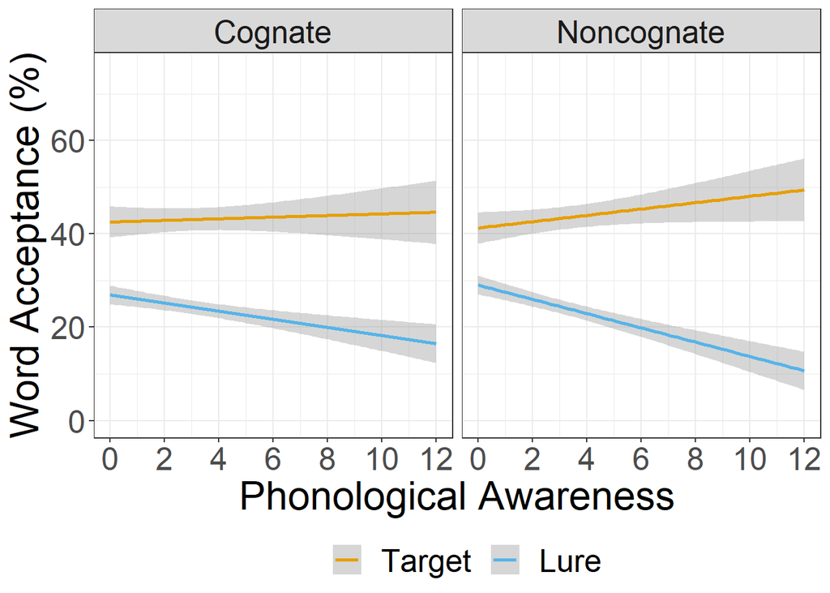

#### Onset/Rhyme Score

```
## Generalized linear mixed model fit by maximum likelihood (Laplace
##   Approximation) [glmerMod]
##  Family: binomial  ( logit )
## Formula: detection ~ 1 + Word_Type * Word_Status * Onset_Rhyme.c + (1 |
##     subject_nr) + (1 | Sentence_Num)
##    Data: Lseg_Htest
## Control: glmerControl(optimizer = "bobyqa")
##
##      AIC      BIC   logLik deviance df.resid
##  10094.2  10166.0  -5037.1  10074.2     9701
##
## Scaled residuals:
##     Min      1Q  Median      3Q     Max
## -2.2348 -0.6121 -0.3255  0.7861  6.7126
##
## Random effects:
##  Groups       Name        Variance Std.Dev.
##  Sentence_Num (Intercept) 0.04009  0.2002
##  subject_nr   (Intercept) 1.42975  1.1957
## Number of obs: 9711, groups:  Sentence_Num, 160; subject_nr, 86
##
## Fixed effects:
##                                        Estimate Std. Error z value Pr(>|z|)
## (Intercept)                           -0.889742   0.133177  -6.681 2.37e-11 ***
## Word_Type1                            -0.041233   0.050978  -0.809    0.419
## Word_Status1                           1.057409   0.051701  20.452  < 2e-16 ***
## Onset_Rhyme.c                         -0.036197   0.031124  -1.163    0.245
## Word_Type1:Word_Status1                0.008291   0.101952   0.081    0.935
## Word_Type1:Onset_Rhyme.c               0.018786   0.012050   1.559    0.119
## Word_Status1:Onset_Rhyme.c             0.098171   0.012282   7.993 1.32e-15 ***
## Word_Type1:Word_Status1:Onset_Rhyme.c  0.030921   0.024109   1.283    0.200
## ---
## Signif. codes:  0 '***' 0.001 '**' 0.01 '*' 0.05 '.' 0.1 ' ' 1
##
## Correlation of Fixed Effects:
##             (Intr) Wrd_T1 Wrd_S1 Ons_R. Wr_T1:W_S1 W_T1:O W_S1:O
## Word_Type1   0.001
## Word_Stats1  0.030  0.000
## Onst_Rhym.c  0.008 -0.001 -0.019
## Wrd_T1:W_S1  0.000  0.216  0.002 -0.001
## Wrd_T1:O_R. -0.001  0.021 -0.003  0.001 -0.072
## Wrd_S1:O_R. -0.019 -0.003  0.033  0.025 -0.001      0.001
## W_T1:W_S1:O -0.002 -0.072  0.000  0.000  0.021      0.180  0.009
```

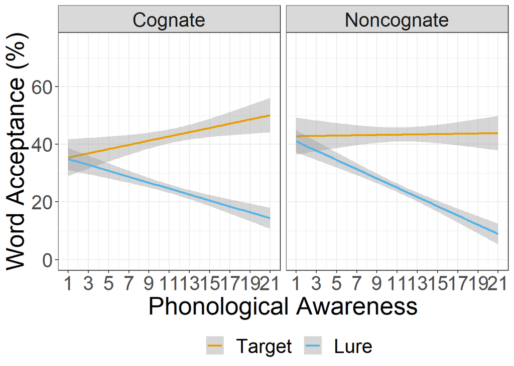

### Grade

Approximation for now for L1 knowledge

```
## Generalized linear mixed model fit by maximum likelihood (Laplace
##   Approximation) [glmerMod]
##  Family: binomial  ( logit )
## Formula: detection ~ 1 + Word_Type * Word_Status * DEMO_SchoolGrade +
##     (1 | subject_nr) + (1 | Sentence_Num)
##    Data: Lseg_Htest
## Control: glmerControl(optimizer = "bobyqa")
##
##      AIC      BIC   logLik deviance df.resid
##  10273.8  10345.8  -5126.9  10253.8     9930
##
## Scaled residuals:
##     Min      1Q  Median      3Q     Max
## -2.0250 -0.6070 -0.3504  0.7794  6.3496
##
## Random effects:
##  Groups       Name        Variance Std.Dev.
##  Sentence_Num (Intercept) 0.03709  0.1926
##  subject_nr   (Intercept) 1.42915  1.1955
## Number of obs: 9940, groups:  Sentence_Num, 160; subject_nr, 88
##
## Fixed effects:
##                                            Estimate Std. Error z value Pr(>|z|)
## (Intercept)                               -0.918744   0.132087  -6.956 3.51e-12
## Word_Type1                                -0.034010   0.050674  -0.671    0.502
## Word_Status1                               1.094046   0.051424  21.275  < 2e-16
## DEMO_SchoolGrade1                          0.234256   0.262193   0.893    0.372
## Word_Type1:Word_Status1                    0.009454   0.101354   0.093    0.926
## Word_Type1:DEMO_SchoolGrade1               0.012392   0.101326   0.122    0.903
## Word_Status1:DEMO_SchoolGrade1            -0.796123   0.102721  -7.750 9.17e-15
## Word_Type1:Word_Status1:DEMO_SchoolGrade1  0.058421   0.202621   0.288    0.773
##
## (Intercept)                               ***
## Word_Type1
## Word_Status1                              ***
## DEMO_SchoolGrade1
## Word_Type1:Word_Status1
## Word_Type1:DEMO_SchoolGrade1
## Word_Status1:DEMO_SchoolGrade1            ***
## Word_Type1:Word_Status1:DEMO_SchoolGrade1
## ---
## Signif. codes:  0 '***' 0.001 '**' 0.01 '*' 0.05 '.' 0.1 ' ' 1
##
## Correlation of Fixed Effects:
##             (Intr) Wrd_T1 Wrd_S1 DEMO_S Wr_T1:W_S1 W_T1:D W_S1:D
## Word_Type1   0.001
## Word_Stats1  0.026 -0.002
## DEMO_SchlG1 -0.088 -0.001  0.014
## Wrd_T1:W_S1  0.000  0.199  0.001  0.000
## W_T1:DEMO_S -0.001 -0.089  0.000  0.001  0.059
## W_S1:DEMO_S  0.015 -0.001 -0.102  0.029 -0.005     -0.004
## W_T1:W_S1:D  0.000  0.059 -0.006  0.000 -0.089      0.200  0.003
```

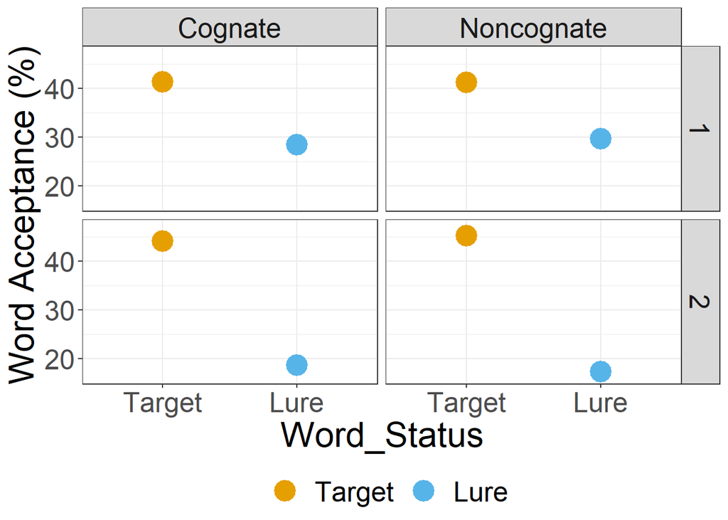

### Age

Approximation for now for L1 knowledge

```
## Generalized linear mixed model fit by maximum likelihood (Laplace
##   Approximation) [glmerMod]
##  Family: binomial  ( logit )
## Formula: detection ~ 1 + Word_Type * Word_Status * DEMO_AgeYears.c + (1 |
##     subject_nr) + (1 | Sentence_Num)
##    Data: Lseg_Htest
## Control: glmerControl(optimizer = "bobyqa")
##
##      AIC      BIC   logLik deviance df.resid
##  10011.1  10082.8  -4995.6   9991.1     9584
##
## Scaled residuals:
##     Min      1Q  Median      3Q     Max
## -1.9690 -0.6141 -0.3472  0.7807  6.0865
##
## Random effects:
##  Groups       Name        Variance Std.Dev.
##  Sentence_Num (Intercept) 0.04152  0.2038
##  subject_nr   (Intercept) 1.45477  1.2061
## Number of obs: 9594, groups:  Sentence_Num, 160; subject_nr, 85
##
## Fixed effects:
##                                         Estimate Std. Error z value Pr(>|z|)
## (Intercept)                             -0.87850    0.13505  -6.505 7.76e-11
## Word_Type1                              -0.03467    0.05115  -0.678    0.498
## Word_Status1                             1.03859    0.05181  20.048  < 2e-16
## DEMO_AgeYears.c                         -0.04834    0.17832  -0.271    0.786
## Word_Type1:Word_Status1                  0.01171    0.10230   0.114    0.909
## Word_Type1:DEMO_AgeYears.c              -0.04028    0.06786  -0.594    0.553
## Word_Status1:DEMO_AgeYears.c             0.50681    0.06871   7.376 1.63e-13
## Word_Type1:Word_Status1:DEMO_AgeYears.c -0.11947    0.13572  -0.880    0.379
##
## (Intercept)                             ***
## Word_Type1
## Word_Status1                            ***
## DEMO_AgeYears.c
## Word_Type1:Word_Status1
## Word_Type1:DEMO_AgeYears.c
## Word_Status1:DEMO_AgeYears.c            ***
## Word_Type1:Word_Status1:DEMO_AgeYears.c
## ---
## Signif. codes:  0 '***' 0.001 '**' 0.01 '*' 0.05 '.' 0.1 ' ' 1
##
## Correlation of Fixed Effects:
##             (Intr) Wrd_T1 Wrd_S1 DEMO_A Wr_T1:W_S1 W_T1:D W_S1:D
## Word_Type1   0.001
## Word_Stats1  0.032 -0.002
## DEMO_AgYrs.  0.004  0.002 -0.013
## Wrd_T1:W_S1 -0.001  0.222 -0.001  0.001
## W_T1:DEMO_A  0.002 -0.005  0.001  0.000 -0.064
## W_S1:DEMO_A -0.014  0.001  0.005  0.035  0.006     -0.007
## W_T1:W_S1:D  0.001 -0.064  0.005 -0.001 -0.006      0.235 -0.004
```

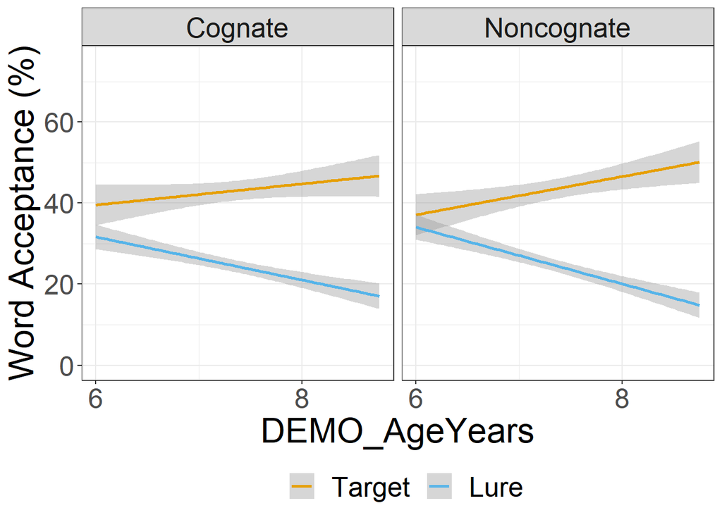

### German Production CLT

Another approximation for L1 knowledge

```
## Generalized linear mixed model fit by maximum likelihood (Laplace
##   Approximation) [glmerMod]
##  Family: binomial  ( logit )
## Formula: detection ~ 1 + Word_Type * Word_Status * Ger_CLT_Prod.c + (1 |
##     subject_nr) + (1 | Sentence_Num)
##    Data: Lseg_Htest
## Control: glmerControl(optimizer = "bobyqa")
##
##      AIC      BIC   logLik deviance df.resid
##  10323.2  10395.2  -5151.6  10303.2     9930
##
## Scaled residuals:
##     Min      1Q  Median      3Q     Max
## -2.4223 -0.6184 -0.3571  0.7795  6.0769
##
## Random effects:
##  Groups       Name        Variance Std.Dev.
##  Sentence_Num (Intercept) 0.03539  0.1881
##  subject_nr   (Intercept) 1.38696  1.1777
## Number of obs: 9940, groups:  Sentence_Num, 160; subject_nr, 88
##
## Fixed effects:
##                                         Estimate Std. Error z value Pr(>|z|)
## (Intercept)                            -0.899666   0.129684  -6.937 3.99e-12
## Word_Type1                             -0.034517   0.050291  -0.686   0.4925
## Word_Status1                            1.064976   0.051046  20.863  < 2e-16
## Ger_CLT_Prod.c                         -0.137184   0.062581  -2.192   0.0284
## Word_Type1:Word_Status1                 0.007922   0.100578   0.079   0.9372
## Word_Type1:Ger_CLT_Prod.c              -0.035840   0.024021  -1.492   0.1357
## Word_Status1:Ger_CLT_Prod.c             0.045943   0.024312   1.890   0.0588
## Word_Type1:Word_Status1:Ger_CLT_Prod.c -0.069922   0.048053  -1.455   0.1456
##
## (Intercept)                            ***
## Word_Type1
## Word_Status1                           ***
## Ger_CLT_Prod.c                         *
## Word_Type1:Word_Status1
## Word_Type1:Ger_CLT_Prod.c
## Word_Status1:Ger_CLT_Prod.c            .
## Word_Type1:Word_Status1:Ger_CLT_Prod.c
## ---
## Signif. codes:  0 '***' 0.001 '**' 0.01 '*' 0.05 '.' 0.1 ' ' 1
##
## Correlation of Fixed Effects:
##             (Intr) Wrd_T1 Wrd_S1 G_CLT_ Wr_T1:W_S1 W_T1:G W_S1:G
## Word_Type1   0.001
## Word_Stats1  0.031  0.000
## Gr_CLT_Prd.  0.010  0.001 -0.010
## Wrd_T1:W_S1  0.000  0.221  0.002  0.001
## W_T1:G_CLT_  0.001  0.021 -0.002  0.003 -0.028
## W_S1:G_CLT_ -0.009  0.000  0.025  0.049 -0.001      0.009
## W_T1:W_S1:G  0.001 -0.028 -0.001  0.002  0.021      0.294  0.017
```

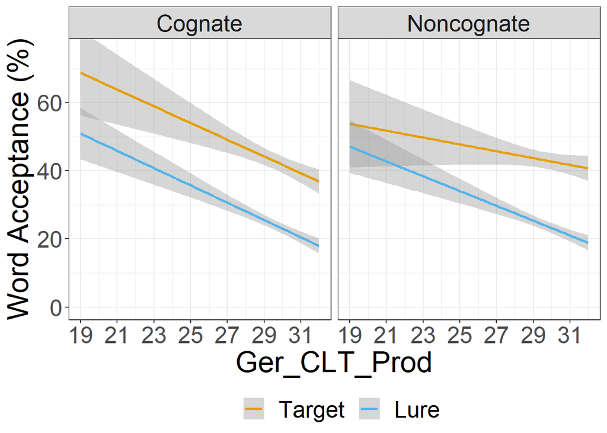

## Participant Variables: Exploratory

### Language Background (Monolingual, Bilingual)

```
## # A tibble: 2 × 2
##   LANG_Bilingual total_participants
##   <fct>                       <int>
## 1 monolingual                    70
## 2 bilingual                      18
```

```
## # A tibble: 1 × 8
##   .y.           group1      group2       n1    n2 statistic    df      p
## * <chr>         <chr>       <chr>     <int> <int>     <dbl> <dbl>  <dbl>
## 1 DEMO_AgeYears monolingual bilingual    68    17      2.49  29.9 0.0187
```

```
## # A tibble: 1 × 8
##   .y.       group1      group2       n1    n2 statistic    df     p
## * <chr>     <chr>       <chr>     <int> <int>     <dbl> <dbl> <dbl>
## 1 RAVENS_IQ monolingual bilingual    68    17    -0.998  23.2 0.329
```

```
## # A tibble: 1 × 8
##   .y.              group1      group2       n1    n2 statistic    df     p
## * <chr>            <chr>       <chr>     <int> <int>     <dbl> <dbl> <dbl>
## 1 WM_BackDigitSpan monolingual bilingual    70    18      1.13  22.5 0.272
```

```
## # A tibble: 1 × 8
##   .y.          group1      group2       n1    n2 statistic    df      p
## * <chr>        <chr>       <chr>     <int> <int>     <dbl> <dbl>  <dbl>
## 1 Ger_CLT_Prod monolingual bilingual    70    18      2.35  18.9 0.0297
```

```
## # A tibble: 1 × 8
##   .y.                group1      group2       n1    n2 statistic    df     p
## * <chr>              <chr>       <chr>     <int> <int>     <dbl> <dbl> <dbl>
## 1 NWRT_total_correct monolingual bilingual    70    18   -0.0658  26.4 0.948
```

```
## # A tibble: 1 × 8
##   .y.                  group1      group2       n1    n2 statistic    df     p
## * <chr>                <chr>       <chr>     <int> <int>     <dbl> <dbl> <dbl>
## 1 Phoneme_Manipulation monolingual bilingual    69    18      1.49  27.8 0.149
```

```
## # A tibble: 1 × 8
##   .y.         group1      group2       n1    n2 statistic    df     p
## * <chr>       <chr>       <chr>     <int> <int>     <dbl> <dbl> <dbl>
## 1 Onset_Rhyme monolingual bilingual    69    17    -0.196  27.4 0.846
```

```
## # A tibble: 1 × 8
##   .y.           group1      group2       n1    n2 statistic    df     p
## * <chr>         <chr>       <chr>     <int> <int>     <dbl> <dbl> <dbl>
## 1 ENG_CLT_score monolingual bilingual    69    18    -0.313  29.2 0.757
```

```
## Generalized linear mixed model fit by maximum likelihood (Laplace
##   Approximation) [glmerMod]
##  Family: binomial  ( logit )
## Formula: detection ~ 1 + Word_Type * Word_Status * LANG_Bilingual + (1 |
##     subject_nr) + (1 | Sentence_Num)
##    Data: Lseg_Htest
## Control: glmerControl(optimizer = "bobyqa")
##
##      AIC      BIC   logLik deviance df.resid
##  10313.0  10385.0  -5146.5  10293.0     9930
##
## Scaled residuals:
##     Min      1Q  Median      3Q     Max
## -2.0981 -0.6267 -0.3495  0.7623  5.9750
##
## Random effects:
##  Groups       Name        Variance Std.Dev.
##  Sentence_Num (Intercept) 0.03529  0.1878
##  subject_nr   (Intercept) 1.37779  1.1738
## Number of obs: 9940, groups:  Sentence_Num, 160; subject_nr, 88
##
## Fixed effects:
##                                           Estimate Std. Error z value Pr(>|z|)
## (Intercept)                             -7.101e-01  1.602e-01  -4.434 9.25e-06
## Word_Type1                              -6.048e-05  6.163e-02  -0.001   0.9992
## Word_Status1                             9.189e-01  6.208e-02  14.802  < 2e-16
## LANG_Bilingual1                         -6.406e-01  3.189e-01  -2.009   0.0446
## Word_Type1:Word_Status1                  8.941e-02  1.232e-01   0.725   0.4682
## Word_Type1:LANG_Bilingual1              -1.133e-01  1.232e-01  -0.920   0.3578
## Word_Status1:LANG_Bilingual1             4.977e-01  1.239e-01   4.016 5.91e-05
## Word_Type1:Word_Status1:LANG_Bilingual1 -2.703e-01  2.463e-01  -1.097   0.2726
##
## (Intercept)                             ***
## Word_Type1
## Word_Status1                            ***
## LANG_Bilingual1                         *
## Word_Type1:Word_Status1
## Word_Type1:LANG_Bilingual1
## Word_Status1:LANG_Bilingual1            ***
## Word_Type1:Word_Status1:LANG_Bilingual1
## ---
## Signif. codes:  0 '***' 0.001 '**' 0.01 '*' 0.05 '.' 0.1 ' ' 1
##
## Correlation of Fixed Effects:
##             (Intr) Wrd_T1 Wrd_S1 LANG_B Wr_T1:W_S1 W_T1:L W_S1:L
## Word_Type1   0.000
## Word_Stats1  0.049  0.000
## LANG_Blngl1 -0.590  0.001 -0.040
## Wrd_T1:W_S1 -0.001  0.289  0.000  0.002
## W_T1:LANG_B  0.001 -0.578 -0.001  0.000 -0.209
## W_S1:LANG_B -0.039  0.000 -0.570  0.050  0.000     -0.001
## W_T1:W_S1:L  0.001 -0.209  0.000 -0.001 -0.578      0.291  0.001
```

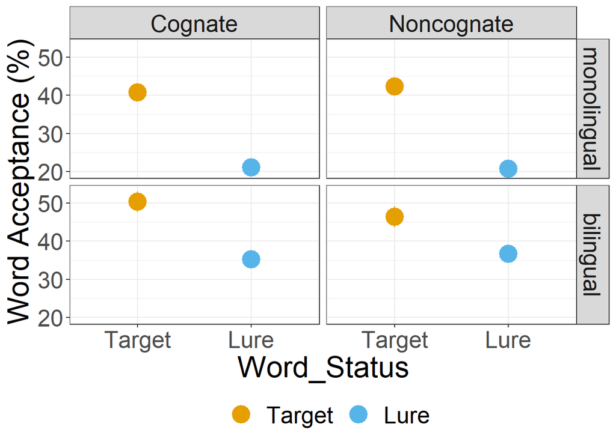

### English CLT

#### Overall performance

```
## Generalized linear mixed model fit by maximum likelihood (Laplace
##   Approximation) [glmerMod]
##  Family: binomial  ( logit )
## Formula: detection ~ 1 + Word_Type * Word_Status * ENG_CLT_score.c + (1 |
##     subject_nr) + (1 | Sentence_Num)
##    Data: Lseg_Htest
## Control: glmerControl(optimizer = "bobyqa")
##
##      AIC      BIC   logLik deviance df.resid
##  10219.3  10291.3  -5099.7  10199.3     9814
##
## Scaled residuals:
##     Min      1Q  Median      3Q     Max
## -2.2926 -0.6165 -0.3558  0.7877  5.6450
##
## Random effects:
##  Groups       Name        Variance Std.Dev.
##  Sentence_Num (Intercept) 0.03601  0.1898
##  subject_nr   (Intercept) 1.47711  1.2154
## Number of obs: 9824, groups:  Sentence_Num, 160; subject_nr, 87
##
## Fixed effects:
##                                           Estimate Std. Error z value Pr(>|z|)
## (Intercept)                             -0.8939676  0.1343613  -6.653 2.86e-11
## Word_Type1                              -0.0285983  0.0505602  -0.566  0.57165
## Word_Status1                             1.0489382  0.0512987  20.448  < 2e-16
## ENG_CLT_score.c                          0.0006173  0.0132655   0.047  0.96288
## Word_Type1:Word_Status1                  0.0034640  0.1011194   0.034  0.97267
## Word_Type1:ENG_CLT_score.c               0.0019634  0.0049590   0.396  0.69216
## Word_Status1:ENG_CLT_score.c             0.0180442  0.0050257   3.590  0.00033
## Word_Type1:Word_Status1:ENG_CLT_score.c  0.0059911  0.0099191   0.604  0.54585
##
## (Intercept)                             ***
## Word_Type1
## Word_Status1                            ***
## ENG_CLT_score.c
## Word_Type1:Word_Status1
## Word_Type1:ENG_CLT_score.c
## Word_Status1:ENG_CLT_score.c            ***
## Word_Type1:Word_Status1:ENG_CLT_score.c
## ---
## Signif. codes:  0 '***' 0.001 '**' 0.01 '*' 0.05 '.' 0.1 ' ' 1
##
## Correlation of Fixed Effects:
##             (Intr) Wrd_T1 Wrd_S1 ENG_CL Wr_T1:W_S1 W_T1:E W_S1:E
## Word_Type1   0.001
## Word_Stats1  0.031 -0.001
## ENG_CLT_sc.  0.013  0.000 -0.005
## Wrd_T1:W_S1  0.000  0.226  0.000  0.001
## W_T1:ENG_CL  0.001 -0.010  0.005  0.000 -0.032
## W_S1:ENG_CL -0.006  0.006 -0.006  0.036  0.002     -0.005
## W_T1:W_S1:E  0.001 -0.032  0.004  0.000 -0.010      0.237  0.002
```

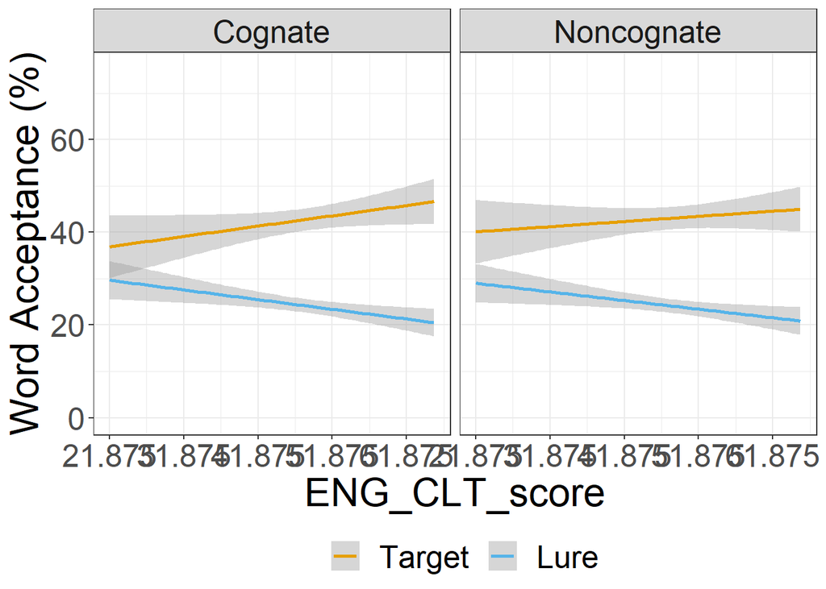

#### Specific performance on cognate words

```
## Generalized linear mixed model fit by maximum likelihood (Laplace
##   Approximation) [glmerMod]
##  Family: binomial  ( logit )
## Formula: detection ~ 1 + Word_Type * Word_Status * ENG_CLT_cognates.c +
##     (1 | subject_nr) + (1 | Sentence_Num)
##    Data: Lseg_Htest
## Control: glmerControl(optimizer = "bobyqa")
##
##      AIC      BIC   logLik deviance df.resid
##  10202.4  10274.3  -5091.2  10182.4     9814
##
## Scaled residuals:
##     Min      1Q  Median      3Q     Max
## -2.2709 -0.6181 -0.3528  0.7841  5.7182
##
## Random effects:
##  Groups       Name        Variance Std.Dev.
##  Sentence_Num (Intercept) 0.03637  0.1907
##  subject_nr   (Intercept) 1.47997  1.2165
## Number of obs: 9824, groups:  Sentence_Num, 160; subject_nr, 87
##
## Fixed effects:
##                                              Estimate Std. Error z value
## (Intercept)                                -0.8963054  0.1344930  -6.664
## Word_Type1                                 -0.0270313  0.0506125  -0.534
## Word_Status1                                1.0519872  0.0513638  20.481
## ENG_CLT_cognates.c                          0.0001771  0.0083909   0.021
## Word_Type1:Word_Status1                     0.0071999  0.1012270   0.071
## Word_Type1:ENG_CLT_cognates.c              -0.0002743  0.0031021  -0.088
## Word_Status1:ENG_CLT_cognates.c             0.0172752  0.0031386   5.504
## Word_Type1:Word_Status1:ENG_CLT_cognates.c -0.0001662  0.0062047  -0.027
##                                            Pr(>|z|)
## (Intercept)                                2.66e-11 ***
## Word_Type1                                    0.593
## Word_Status1                                < 2e-16 ***
## ENG_CLT_cognates.c                            0.983
## Word_Type1:Word_Status1                       0.943
## Word_Type1:ENG_CLT_cognates.c                 0.930
## Word_Status1:ENG_CLT_cognates.c            3.71e-08 ***
## Word_Type1:Word_Status1:ENG_CLT_cognates.c    0.979
## ---
## Signif. codes:  0 '***' 0.001 '**' 0.01 '*' 0.05 '.' 0.1 ' ' 1
##
## Correlation of Fixed Effects:
##             (Intr) Wrd_T1 Wrd_S1 ENG_CL Wr_T1:W_S1 W_T1:E W_S1:E
## Word_Type1   0.000
## Word_Stats1  0.031 -0.002
## ENG_CLT_cg.  0.008  0.001 -0.007
## Wrd_T1:W_S1  0.000  0.223 -0.001  0.001
## W_T1:ENG_CL  0.001  0.006  0.005  0.000 -0.039
## W_S1:ENG_CL -0.009  0.006  0.014  0.037  0.005     -0.011
## W_T1:W_S1:E  0.001 -0.039  0.006 -0.001  0.006      0.246 -0.005
```

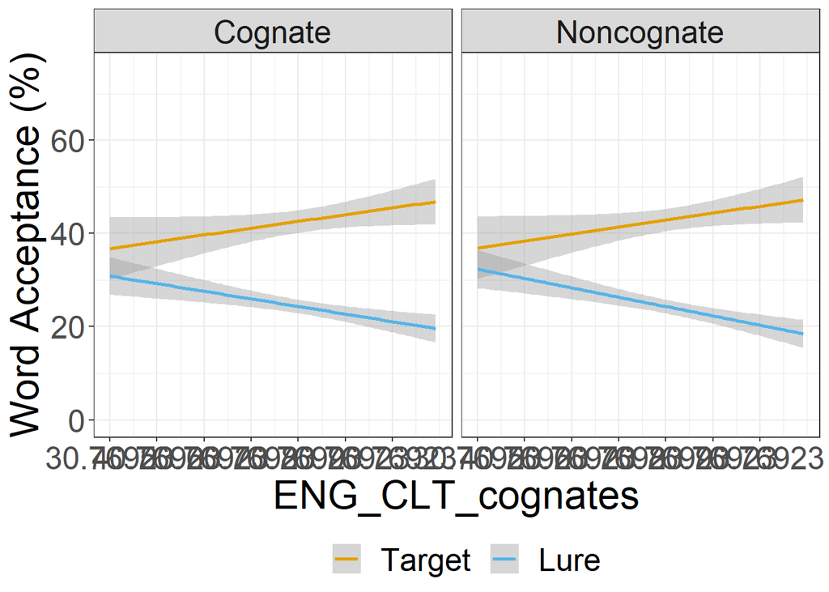

#### Difference score (Prop cognates correct – prop noncognates correct )

difference score where 0 is similar performance between cognates and noncognates

```
## Generalized linear mixed model fit by maximum likelihood (Laplace
##   Approximation) [glmerMod]
##  Family: binomial  ( logit )
## Formula: detection ~ 1 + Word_Type * Word_Status * English_CLT_diffscore.c +
##     (1 | subject_nr) + (1 | Sentence_Num)
##    Data: Lseg_Htest
## Control: glmerControl(optimizer = "bobyqa")
##
##      AIC      BIC   logLik deviance df.resid
##  10203.5  10275.5  -5091.8  10183.5     9814
##
## Scaled residuals:
##     Min      1Q  Median      3Q     Max
## -2.2837 -0.6199 -0.3530  0.7741  6.1635
##
## Random effects:
##  Groups       Name        Variance Std.Dev.
##  Sentence_Num (Intercept) 0.03612  0.19
##  subject_nr   (Intercept) 1.48806  1.22
## Number of obs: 9824, groups:  Sentence_Num, 160; subject_nr, 87
##
## Fixed effects:
##                                                   Estimate Std. Error z value
## (Intercept)                                     -0.8959018  0.1348332  -6.645
## Word_Type1                                      -0.0274872  0.0506218  -0.543
## Word_Status1                                     1.0567042  0.0514092  20.555
## English_CLT_diffscore.c                         -0.0001377  0.0080864  -0.017
## Word_Type1:Word_Status1                          0.0076190  0.1012488   0.075
## Word_Type1:English_CLT_diffscore.c              -0.0016187  0.0030197  -0.536
## Word_Status1:English_CLT_diffscore.c             0.0163357  0.0030488   5.358
## Word_Type1:Word_Status1:English_CLT_diffscore.c -0.0039578  0.0060406  -0.655
##                                                 Pr(>|z|)
## (Intercept)                                     3.04e-11 ***
## Word_Type1                                         0.587
## Word_Status1                                     < 2e-16 ***
## English_CLT_diffscore.c                            0.986
## Word_Type1:Word_Status1                            0.940
## Word_Type1:English_CLT_diffscore.c                 0.592
## Word_Status1:English_CLT_diffscore.c            8.41e-08 ***
## Word_Type1:Word_Status1:English_CLT_diffscore.c    0.512
## ---
## Signif. codes:  0 '***' 0.001 '**' 0.01 '*' 0.05 '.' 0.1 ' ' 1
##
## Correlation of Fixed Effects:
##             (Intr) Wrd_T1 Wrd_S1 E_CLT_ Wr_T1:W_S1 W_T1:E W_S1:E
## Word_Type1   0.000
## Word_Stats1  0.030 -0.002
## Engls_CLT_.  0.000  0.001 -0.007
## Wrd_T1:W_S1  0.000  0.223 -0.001  0.002
## W_T1:E_CLT_  0.001  0.021  0.003  0.000 -0.033
## W_S1:E_CLT_ -0.009  0.004  0.032  0.036  0.006     -0.012
## W_T1:W_S1:E  0.002 -0.033  0.005 -0.003  0.021      0.243 -0.008
```

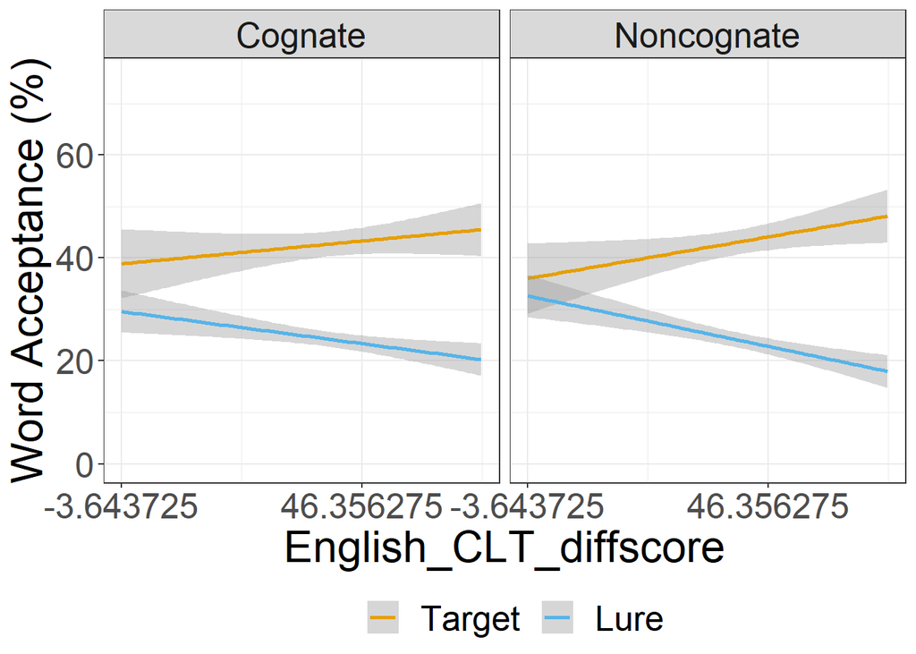

### Ravens Matricies IQ score

```
## Generalized linear mixed model fit by maximum likelihood (Laplace
##   Approximation) [glmerMod]
##  Family: binomial  ( logit )
## Formula: detection ~ 1 + Word_Type * Word_Status * RAVENS_IQ.c + (1 |
##     subject_nr) + (1 | Sentence_Num)
##    Data: Lseg_Htest
## Control: glmerControl(optimizer = "bobyqa")
##
##      AIC      BIC   logLik deviance df.resid
##  10036.5  10108.2  -5008.3  10016.5     9584
##
## Scaled residuals:
##     Min      1Q  Median      3Q     Max
## -2.4038 -0.6348 -0.3425  0.8046  8.0687
##
## Random effects:
##  Groups       Name        Variance Std.Dev.
##  Sentence_Num (Intercept) 0.04092  0.2023
##  subject_nr   (Intercept) 1.39783  1.1823
## Number of obs: 9594, groups:  Sentence_Num, 160; subject_nr, 85
##
## Fixed effects:
##                                      Estimate Std. Error z value Pr(>|z|)
## (Intercept)                         -0.881104   0.132572  -6.646 3.01e-11 ***
## Word_Type1                          -0.036864   0.051219  -0.720   0.4717
## Word_Status1                         1.065852   0.052024  20.488  < 2e-16 ***
## RAVENS_IQ.c                         -0.025624   0.011365  -2.255   0.0242 *
## Word_Type1:Word_Status1              0.001772   0.102436   0.017   0.9862
## Word_Type1:RAVENS_IQ.c              -0.000699   0.004714  -0.148   0.8821
## Word_Status1:RAVENS_IQ.c             0.024093   0.004846   4.971 6.65e-07 ***
## Word_Type1:Word_Status1:RAVENS_IQ.c -0.003196   0.009427  -0.339   0.7345
## ---
## Signif. codes:  0 '***' 0.001 '**' 0.01 '*' 0.05 '.' 0.1 ' ' 1
##
## Correlation of Fixed Effects:
##             (Intr) Wrd_T1 Wrd_S1 RAVENS Wr_T1:W_S1 W_T1:R W_S1:R
## Word_Type1   0.001
## Word_Stats1  0.028 -0.001
## RAVENS_IQ.c  0.017  0.001 -0.021
## Wrd_T1:W_S1  0.000  0.213  0.000  0.001
## W_T1:RAVENS  0.001  0.077  0.003  0.003 -0.054
## W_S1:RAVENS -0.021  0.002  0.092  0.003  0.002      0.002
## W_T1:W_S1:R  0.000 -0.054  0.003  0.003  0.077      0.150  0.010
```

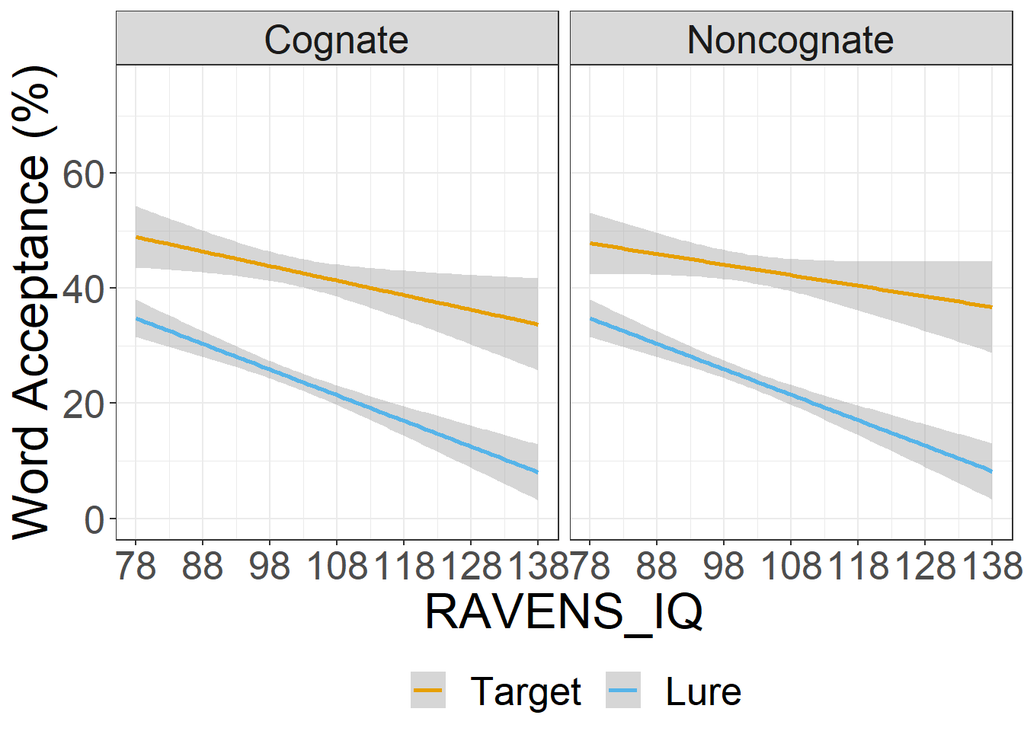

### Backwards Digit Span

```
## Generalized linear mixed model fit by maximum likelihood (Laplace
##   Approximation) [glmerMod]
##  Family: binomial  ( logit )
## Formula: detection ~ 1 + Word_Type * Word_Status * WM_BackDigitSpan.c +
##     (1 | subject_nr) + (1 | Sentence_Num)
##    Data: Lseg_Htest
## Control: glmerControl(optimizer = "bobyqa")
##
##      AIC      BIC   logLik deviance df.resid
##  10281.7  10353.8  -5130.9  10261.7     9930
##
## Scaled residuals:
##     Min      1Q  Median      3Q     Max
## -2.3111 -0.6111 -0.3448  0.7938  5.7900
##
## Random effects:
##  Groups       Name        Variance Std.Dev.
##  Sentence_Num (Intercept) 0.03583  0.1893
##  subject_nr   (Intercept) 1.39768  1.1822
## Number of obs: 9940, groups:  Sentence_Num, 160; subject_nr, 88
##
## Fixed effects:
##                                            Estimate Std. Error z value Pr(>|z|)
## (Intercept)                                -0.90415    0.13017  -6.946 3.76e-12
## Word_Type1                                 -0.02742    0.05042  -0.544  0.58651
## Word_Status1                                1.04996    0.05112  20.541  < 2e-16
## WM_BackDigitSpan.c                         -0.20445    0.14712  -1.390  0.16462
## Word_Type1:Word_Status1                     0.03131    0.10085   0.310  0.75621
## Word_Type1:WM_BackDigitSpan.c              -0.17410    0.05833  -2.985  0.00284
## Word_Status1:WM_BackDigitSpan.c             0.37714    0.05898   6.394 1.61e-10
## Word_Type1:Word_Status1:WM_BackDigitSpan.c -0.19829    0.11659  -1.701  0.08897
##
## (Intercept)                                ***
## Word_Type1
## Word_Status1                               ***
## WM_BackDigitSpan.c
## Word_Type1:Word_Status1
## Word_Type1:WM_BackDigitSpan.c              **
## Word_Status1:WM_BackDigitSpan.c            ***
## Word_Type1:Word_Status1:WM_BackDigitSpan.c .
## ---
## Signif. codes:  0 '***' 0.001 '**' 0.01 '*' 0.05 '.' 0.1 ' ' 1
##
## Correlation of Fixed Effects:
##             (Intr) Wrd_T1 Wrd_S1 WM_BDS Wr_T1:W_S1 W_T1:WM W_S1:W
## Word_Type1   0.001
## Word_Stats1  0.031 -0.004
## WM_BckDgtS.  0.001  0.002 -0.012
## Wrd_T1:W_S1 -0.001  0.219  0.002 -0.001
## W_T1:WM_BDS  0.002 -0.028 -0.008  0.003 -0.063
## W_S1:WM_BDS -0.012 -0.006 -0.021  0.043  0.008     -0.014
## W_T1:W_S1:W  0.000 -0.063  0.008 -0.001 -0.028      0.244  -0.005
```

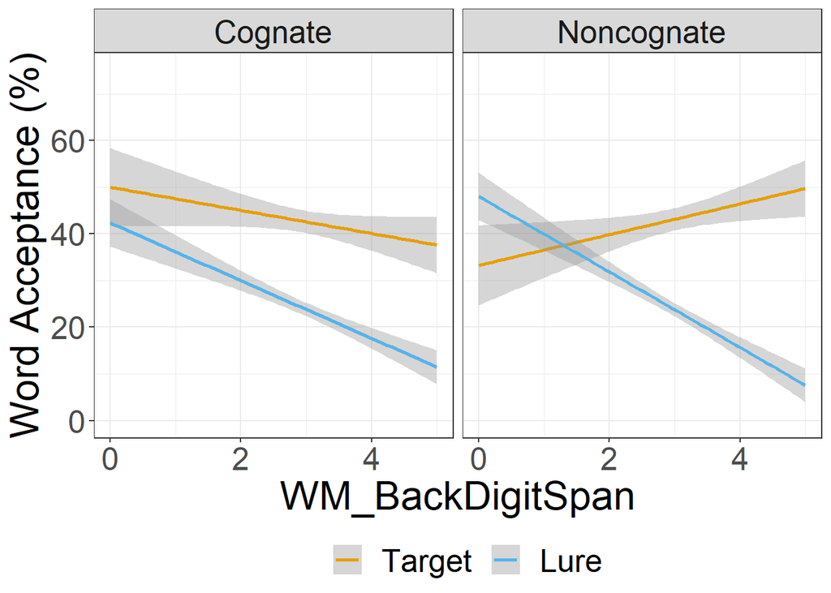

### NonWord Repetition Task

```
## Generalized linear mixed model fit by maximum likelihood (Laplace
##   Approximation) [glmerMod]
##  Family: binomial  ( logit )
## Formula: detection ~ 1 + Word_Type * Word_Status * NWRT_total_correct.c +
##     (1 | subject_nr) + (1 | Sentence_Num)
##    Data: Lseg_Htest
## Control: glmerControl(optimizer = "bobyqa")
##
##      AIC      BIC   logLik deviance df.resid
##  10308.5  10380.5  -5144.2  10288.5     9930
##
## Scaled residuals:
##     Min      1Q  Median      3Q     Max
## -2.5463 -0.6250 -0.3464  0.7760  5.6118
##
## Random effects:
##  Groups       Name        Variance Std.Dev.
##  Sentence_Num (Intercept) 0.0357   0.1889
##  subject_nr   (Intercept) 1.4584   1.2076
## Number of obs: 9940, groups:  Sentence_Num, 160; subject_nr, 88
##
## Fixed effects:
##                                               Estimate Std. Error z value
## (Intercept)                                  -0.900517   0.132782  -6.782
## Word_Type1                                   -0.035335   0.050335  -0.702
## Word_Status1                                  1.059150   0.051114  20.721
## NWRT_total_correct.c                         -0.011452   0.063648  -0.180
## Word_Type1:Word_Status1                       0.010962   0.100668   0.109
## Word_Type1:NWRT_total_correct.c              -0.018349   0.024103  -0.761
## Word_Status1:NWRT_total_correct.c             0.124450   0.024352   5.110
## Word_Type1:Word_Status1:NWRT_total_correct.c -0.004784   0.048208  -0.099
##                                              Pr(>|z|)
## (Intercept)                                  1.19e-11 ***
## Word_Type1                                      0.483
## Word_Status1                                  < 2e-16 ***
## NWRT_total_correct.c                            0.857
## Word_Type1:Word_Status1                         0.913
## Word_Type1:NWRT_total_correct.c                 0.446
## Word_Status1:NWRT_total_correct.c            3.21e-07 ***
## Word_Type1:Word_Status1:NWRT_total_correct.c    0.921
## ---
## Signif. codes:  0 '***' 0.001 '**' 0.01 '*' 0.05 '.' 0.1 ' ' 1
##
## Correlation of Fixed Effects:
##             (Intr) Wrd_T1 Wrd_S1 NWRT__ Wr_T1:W_S1 W_T1:N W_S1:N
## Word_Type1   0.001
## Word_Stats1  0.031 -0.003
## NWRT_ttl_c.  0.005  0.001 -0.009
## Wrd_T1:W_S1 -0.001  0.223  0.001  0.000
## W_T1:NWRT__  0.001 -0.010 -0.006  0.000 -0.036
## W_S1:NWRT__ -0.009 -0.005 -0.001  0.037  0.004      0.001
## W_T1:W_S1:N  0.000 -0.036  0.005  0.000 -0.010      0.241 -0.002
```

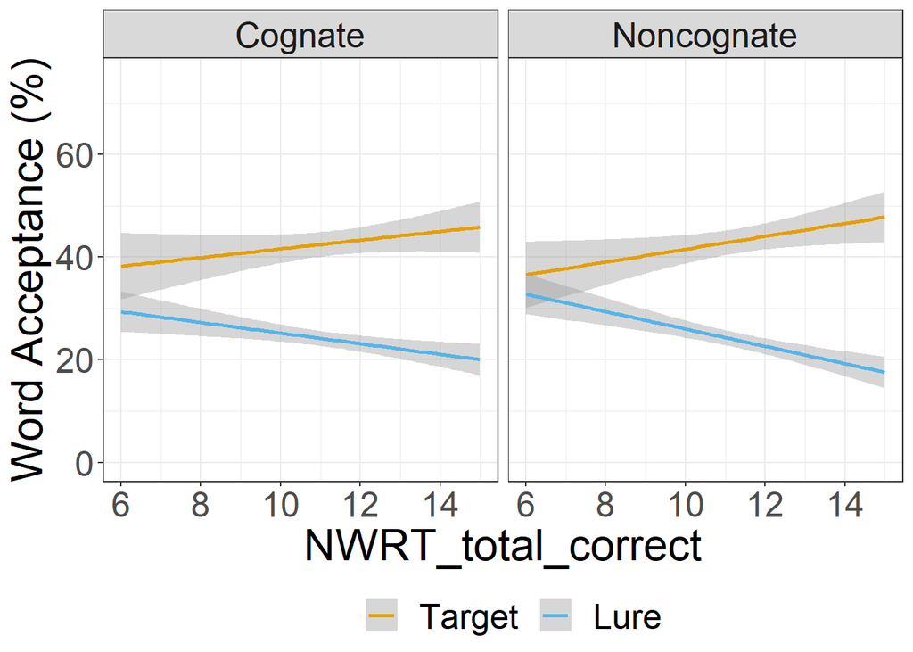

# Recognition: Cognate vs. Non-cognate Following words

## Main Analysis: Utterance Type by Word Status

```
## Generalized linear mixed model fit by maximum likelihood (Laplace
##   Approximation) [glmerMod]
##  Family: binomial  ( logit )
## Formula: detection ~ 1 + Utterance_Type * Word_Status + (1 | subject_nr) +
##     (1 | Sentence_Num)
##    Data: Lseg_Htest
## Control: glmerControl(optimizer = "bobyqa")
##
##      AIC      BIC   logLik deviance df.resid
##  10450.9  10494.1  -5219.4  10438.9     9950
##
## Scaled residuals:
##     Min      1Q  Median      3Q     Max
## -2.9360 -0.6105 -0.3469  0.7547  6.8415
##
## Random effects:
##  Groups       Name        Variance Std.Dev.
##  Sentence_Num (Intercept) 0.0617   0.2484
##  subject_nr   (Intercept) 1.4615   1.2089
## Number of obs: 9956, groups:  Sentence_Num, 160; subject_nr, 88
##
## Fixed effects:
##                              Estimate Std. Error z value Pr(>|z|)
## (Intercept)                  -0.78872    0.13344  -5.911 3.41e-09 ***
## Utterance_Type1              -0.05284    0.04989  -1.059    0.290
## Word_Status1                  1.27723    0.05102  25.035  < 2e-16 ***
## Utterance_Type1:Word_Status1 -0.10475    0.09984  -1.049    0.294
## ---
## Signif. codes:  0 '***' 0.001 '**' 0.01 '*' 0.05 '.' 0.1 ' ' 1
##
## Correlation of Fixed Effects:
##             (Intr) Utt_T1 Wrd_S1
## Uttrnc_Typ1  0.001
## Word_Stats1  0.028 -0.002
## Utt_T1:W_S1  0.001  0.219 -0.003
```

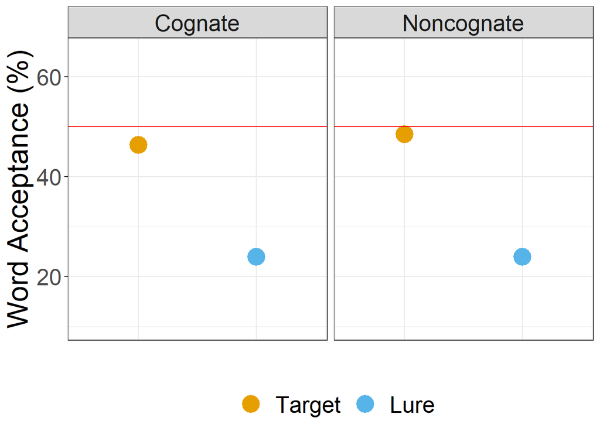

### Role of Phonological Awareness, with control variables Ravens IQ, Working Memory, and German CLT

```
## Generalized linear mixed model fit by maximum likelihood (Laplace
##   Approximation) [glmerMod]
##  Family: binomial  ( logit )
## Formula:
## detection ~ 1 + Utterance_Type * Word_Status * Phoneme_Manipulation.c +
##     RAVENS_IQ + Ger_CLT_Prod.c + WM_BackDigitSpan.c + (1 | subject_nr) +
##     (1 | Sentence_Num)
##    Data: Lseg_Htest
## Control: glmerControl(optimizer = "bobyqa")
##
##      AIC      BIC   logLik deviance df.resid
##  10020.7  10113.7  -4997.3   9994.7     9481
##
## Scaled residuals:
##     Min      1Q  Median      3Q     Max
## -2.7917 -0.6296 -0.3408  0.7775  6.3986
##
## Random effects:
##  Groups       Name        Variance Std.Dev.
##  Sentence_Num (Intercept) 0.06233  0.2497
##  subject_nr   (Intercept) 1.24293  1.1149
## Number of obs: 9494, groups:  Sentence_Num, 160; subject_nr, 84
##
## Fixed effects:
##                                                     Estimate Std. Error z value
## (Intercept)                                          2.12267    1.10993   1.912
## Utterance_Type1                                     -0.05090    0.05108  -0.996
## Word_Status1                                         1.23565    0.05209  23.722
## Phoneme_Manipulation.c                               0.04790    0.04134   1.159
## RAVENS_IQ                                           -0.02856    0.01093  -2.614
## Ger_CLT_Prod.c                                      -0.14365    0.06405  -2.243
## WM_BackDigitSpan.c                                  -0.13518    0.16441  -0.822
## Utterance_Type1:Word_Status1                        -0.10266    0.10218  -1.005
## Utterance_Type1:Phoneme_Manipulation.c               0.01346    0.01497   0.900
## Word_Status1:Phoneme_Manipulation.c                  0.11188    0.01526   7.333
## Utterance_Type1:Word_Status1:Phoneme_Manipulation.c -0.05826    0.02991  -1.948
##                                                     Pr(>|z|)
## (Intercept)                                          0.05582 .
## Utterance_Type1                                      0.31908
## Word_Status1                                         < 2e-16 ***
```

[output cut: 23 more lines]

```
##             W_S1:P
## Uttrnc_Typ1
## Word_Stats1
## Phnm_Mnplt.
## RAVENS_IQ
## Gr_CLT_Prd.
## WM_BckDgtS.
## Utt_T1:W_S1
## Utt_T1:P_M.
## Wrd_S1:P_M.
## U_T1:W_S1:P -0.031
## optimizer (bobyqa) convergence code: 1 (bobyqa -- maximum number of function evaluations exceeded)
## Model failed to converge with max|grad| = 0.00298108 (tol = 0.002, component 1)
## Model is nearly unidentifiable: very large eigenvalue
##  - Rescale variables?
```

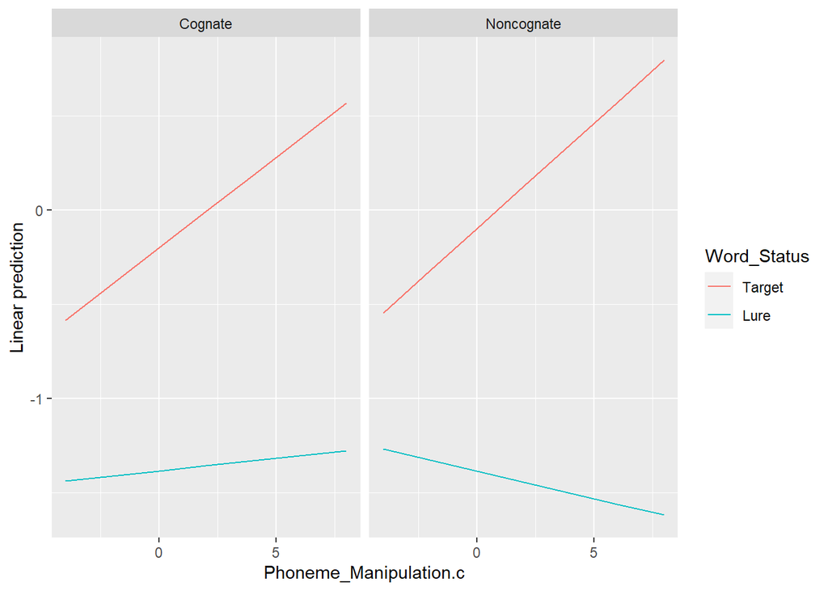

### *d’* analyses

```
## Linear mixed model fit by REML. t-tests use Satterthwaite's method [
## lmerModLmerTest]
## Formula: dprime ~ 1 + Utterance_Type + Phoneme_Manipulation.c + RAVENS_IQ +
##     Ger_CLT_Prod.c + WM_BackDigitSpan.c + (1 | subject_nr)
##    Data: d_calc
##
## REML criterion at convergence: 331.1
##
## Scaled residuals:
##      Min       1Q   Median       3Q      Max
## -2.36404 -0.43821  0.03075  0.47053  2.20277
##
## Random effects:
##  Groups     Name        Variance Std.Dev.
##  subject_nr (Intercept) 0.2994   0.5472
##  Residual               0.1727   0.4155
## Number of obs: 168, groups:  subject_nr, 84
##
## Fixed effects:
##                         Estimate Std. Error        df t value Pr(>|t|)
## (Intercept)             0.141659   0.595871 78.999999   0.238   0.8127
## Utterance_Type1        -0.090698   0.064119 83.000002  -1.415   0.1610
## Phoneme_Manipulation.c  0.040156   0.022443 78.999997   1.789   0.0774 .
## RAVENS_IQ               0.005835   0.005860 78.999999   0.996   0.3224
## Ger_CLT_Prod.c         -0.009049   0.034703 78.999997  -0.261   0.7950
## WM_BackDigitSpan.c      0.221888   0.088638 78.999997   2.503   0.0144 *
## ---
## Signif. codes:  0 '***' 0.001 '**' 0.01 '*' 0.05 '.' 0.1 ' ' 1
##
## Correlation of Fixed Effects:
##             (Intr) Utt_T1 Phn_M. RAVENS G_CLT_
## Uttrnc_Typ1  0.000
## Phnm_Mnplt.  0.144  0.000
## RAVENS_IQ   -0.994  0.000 -0.144
## Gr_CLT_Prd. -0.067  0.000 -0.056  0.068
## WM_BckDgtS.  0.043  0.000 -0.382 -0.045 -0.299
```

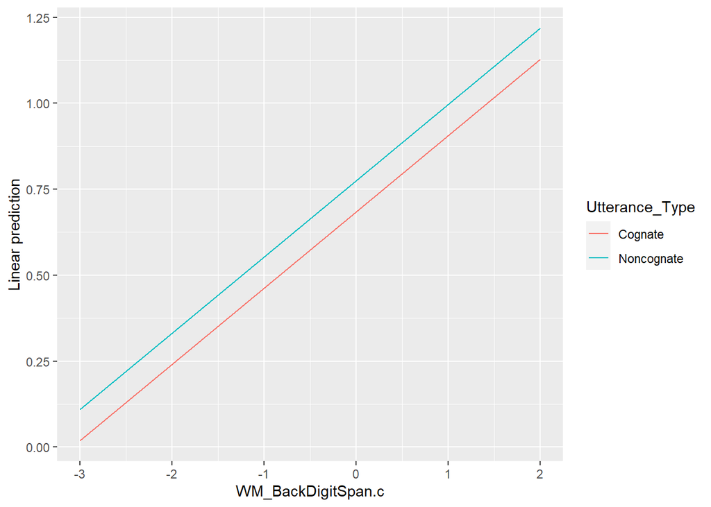

## Experiment Task Variables

### Trial

```
## Generalized linear mixed model fit by maximum likelihood (Laplace
##   Approximation) [glmerMod]
##  Family: binomial  ( logit )
## Formula: detection ~ 1 + Utterance_Type * Word_Status * Trial.c + (1 |
##     subject_nr) + (1 | Sentence_Num)
##    Data: Lseg_Htest
## Control: glmerControl(optimizer = "bobyqa")
##
##      AIC      BIC   logLik deviance df.resid
##  10447.6  10519.6  -5213.8  10427.6     9946
##
## Scaled residuals:
##     Min      1Q  Median      3Q     Max
## -3.1242 -0.6093 -0.3452  0.7504  7.2636
##
## Random effects:
##  Groups       Name        Variance Std.Dev.
##  Sentence_Num (Intercept) 0.06182  0.2486
##  subject_nr   (Intercept) 1.46940  1.2122
## Number of obs: 9956, groups:  Sentence_Num, 160; subject_nr, 88
##
## Fixed effects:
##                                        Estimate Std. Error z value Pr(>|z|)
## (Intercept)                          -0.7883747  0.1337799  -5.893 3.79e-09 ***
## Utterance_Type1                      -0.0567260  0.0499570  -1.135  0.25617
## Word_Status1                          1.2805790  0.0510888  25.066  < 2e-16 ***
## Trial.c                              -0.0004885  0.0005415  -0.902  0.36702
## Utterance_Type1:Word_Status1         -0.1104766  0.0999658  -1.105  0.26910
## Utterance_Type1:Trial.c               0.0016726  0.0010845   1.542  0.12301
## Word_Status1:Trial.c                 -0.0031407  0.0010833  -2.899  0.00374 **
## Utterance_Type1:Word_Status1:Trial.c -0.0009374  0.0021726  -0.431  0.66611
## ---
## Signif. codes:  0 '***' 0.001 '**' 0.01 '*' 0.05 '.' 0.1 ' ' 1
##
## Correlation of Fixed Effects:
##             (Intr) Utt_T1 Wrd_S1 Tril.c Ut_T1:W_S1 U_T1:T W_S1:T
## Uttrnc_Typ1  0.001
## Word_Stats1  0.028 -0.003
## Trial.c     -0.001  0.015 -0.004
## Utt_T1:W_S1  0.001  0.220 -0.003  0.025
## Uttrn_T1:T.  0.002 -0.014  0.028 -0.002 -0.002
## Wrd_Stt1:T.  0.002  0.026 -0.020  0.222  0.015     -0.013
## U_T1:W_S1:T  0.005 -0.002  0.013 -0.013 -0.014      0.221  0.000
## optimizer (bobyqa) convergence code: 0 (OK)
## Model is nearly unidentifiable: very large eigenvalue
##  - Rescale variables?
```

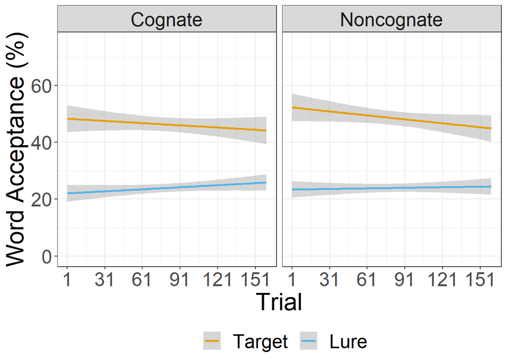

### Counterbalance List

```
## # A tibble: 8 × 2
##   List  total_participants
##   <fct>              <int>
## 1 A                     13
## 2 B                     10
## 3 C                     12
## 4 D                      6
## 5 E                     13
## 6 F                     14
## 7 G                     10
## 8 H                     10
```

```
## Generalized linear mixed model fit by maximum likelihood (Laplace
##   Approximation) [glmerMod]
##  Family: binomial  ( logit )
## Formula:
## detection ~ 1 + Utterance_Type * Word_Status * List + (1 | subject_nr) +
##     (1 | Sentence_Num)
##    Data: Lseg_Htest
## Control: glmerControl(optimizer = "bobyqa")
##
##      AIC      BIC   logLik deviance df.resid
##  10455.0  10700.0  -5193.5  10387.0     9922
##
## Scaled residuals:
##     Min      1Q  Median      3Q     Max
## -3.3518 -0.6025 -0.3497  0.7567  7.4729
##
## Random effects:
##  Groups       Name        Variance Std.Dev.
##  Sentence_Num (Intercept) 0.05675  0.2382
##  subject_nr   (Intercept) 1.32154  1.1496
## Number of obs: 9956, groups:  Sentence_Num, 160; subject_nr, 88
##
## Fixed effects:
##                                    Estimate Std. Error z value Pr(>|z|)
## (Intercept)                        -0.82927    0.32701  -2.536  0.01122 *
## Utterance_Type1                    -0.30432    0.13739  -2.215  0.02676 *
## Word_Status1                        1.23277    0.13867   8.890  < 2e-16 ***
## ListB                              -0.52066    0.49619  -1.049  0.29404
## ListC                               0.63672    0.47197   1.349  0.17731
## ListD                               0.73297    0.57888   1.266  0.20545
## ListE                               0.11983    0.46211   0.259  0.79539
## ListF                              -0.33635    0.45413  -0.741  0.45891
## ListG                               0.17625    0.49416   0.357  0.72135
## ListH                              -0.15716    0.49599  -0.317  0.75135
## Utterance_Type1:Word_Status1       -0.18978    0.27265  -0.696  0.48640
## Utterance_Type1:ListB               0.15864    0.20999   0.755  0.44996
## Utterance_Type1:ListC               0.16292    0.19701   0.827  0.40827
## Utterance_Type1:ListD               0.54297    0.23955   2.267  0.02341 *
## Utterance_Type1:ListE               0.24730    0.20440   1.210  0.22632
## Utterance_Type1:ListF               0.39805    0.19944   1.996  0.04595 *
## Utterance_Type1:ListG               0.23688    0.20278   1.168  0.24274
## Utterance_Type1:ListH               0.45601    0.19972   2.283  0.02242 *
## Word_Status1:ListB                  0.04954    0.21865   0.227  0.82074
## Word_Status1:ListC                 -0.01231    0.20504  -0.060  0.95212
## Word_Status1:ListD                  0.72105    0.24012   3.003  0.00268 **
## Word_Status1:ListE                  0.38865    0.18752   2.073  0.03821 *
## Word_Status1:ListF                 -0.16023    0.19649  -0.815  0.41482
## Word_Status1:ListG                 -0.15693    0.21056  -0.745  0.45610
## Word_Status1:ListH                 -0.22879    0.20711  -1.105  0.26930
## Utterance_Type1:Word_Status1:ListB -0.26564    0.42902  -0.619  0.53580
## Utterance_Type1:Word_Status1:ListC  0.70481    0.39164   1.800  0.07192 .
## Utterance_Type1:Word_Status1:ListD  0.11233    0.46618   0.241  0.80959
## Utterance_Type1:Word_Status1:ListE  0.11121    0.40451   0.275  0.78337
## Utterance_Type1:Word_Status1:ListF -0.07295    0.38364  -0.190  0.84918
## Utterance_Type1:Word_Status1:ListG  0.05425    0.40348   0.134  0.89305
## Utterance_Type1:Word_Status1:ListH -0.03125    0.40881  -0.076  0.93908
## ---
## Signif. codes:  0 '***' 0.001 '**' 0.01 '*' 0.05 '.' 0.1 ' ' 1
## optimizer (bobyqa) convergence code: 0 (OK)
## maxfun < 10 * length(par)^2 is not recommended.
```

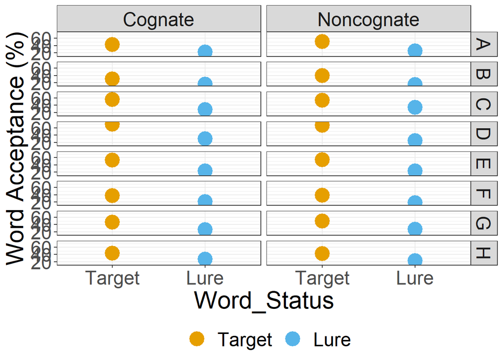

### Position in Sentence

```
## Generalized linear mixed model fit by maximum likelihood (Laplace
##   Approximation) [glmerMod]
##  Family: binomial  ( logit )
## Formula: detection ~ 1 + Utterance_Type * Word_Status * target_position +
##     (1 | subject_nr) + (1 | Sentence_Num)
##    Data: Lseg_Htest
## Control: glmerControl(optimizer = "bobyqa")
##
##      AIC      BIC   logLik deviance df.resid
##  10428.0  10500.1  -5204.0  10408.0     9946
##
## Scaled residuals:
##     Min      1Q  Median      3Q     Max
## -2.8742 -0.6128 -0.3443  0.7499  7.0906
##
## Random effects:
##  Groups       Name        Variance Std.Dev.
##  Sentence_Num (Intercept) 0.05414  0.2327
##  subject_nr   (Intercept) 1.47617  1.2150
## Number of obs: 9956, groups:  Sentence_Num, 160; subject_nr, 88
##
## Fixed effects:
##                                               Estimate Std. Error z value
## (Intercept)                                   -0.78955    0.13390  -5.897
## Utterance_Type1                               -0.05391    0.05001  -1.078
## Word_Status1                                   1.27881    0.05114  25.008
## target_position1                               0.22025    0.06215   3.544
## Utterance_Type1:Word_Status1                  -0.10673    0.10006  -1.067
## Utterance_Type1:target_position1              -0.21056    0.10006  -2.104
## Word_Status1:target_position1                  0.43320    0.10037   4.316
## Utterance_Type1:Word_Status1:target_position1 -0.17254    0.20023  -0.862
##                                               Pr(>|z|)
## (Intercept)                                   3.71e-09 ***
## Utterance_Type1                               0.280998
## Word_Status1                                   < 2e-16 ***
## target_position1                              0.000395 ***
## Utterance_Type1:Word_Status1                  0.286159
## Utterance_Type1:target_position1              0.035348 *
## Word_Status1:target_position1                 1.59e-05 ***
## Utterance_Type1:Word_Status1:target_position1 0.388825
## ---
## Signif. codes:  0 '***' 0.001 '**' 0.01 '*' 0.05 '.' 0.1 ' ' 1
##
## Correlation of Fixed Effects:
##             (Intr) Utt_T1 Wrd_S1 trgt_1 Ut_T1:W_S1 U_T1:_ W_S1:_
## Uttrnc_Typ1  0.000
## Word_Stats1  0.028 -0.004
## targt_pstn1 -0.002  0.001  0.009
## Utt_T1:W_S1  0.001  0.222 -0.005 -0.008
## Uttrn_T1:_1  0.002  0.004 -0.013 -0.004  0.001
## Wrd_Stt1:_1 -0.004 -0.011  0.014  0.181  0.002     -0.003
## U_T1:W_S1:_ -0.001  0.001 -0.001 -0.002  0.004      0.222 -0.005
```

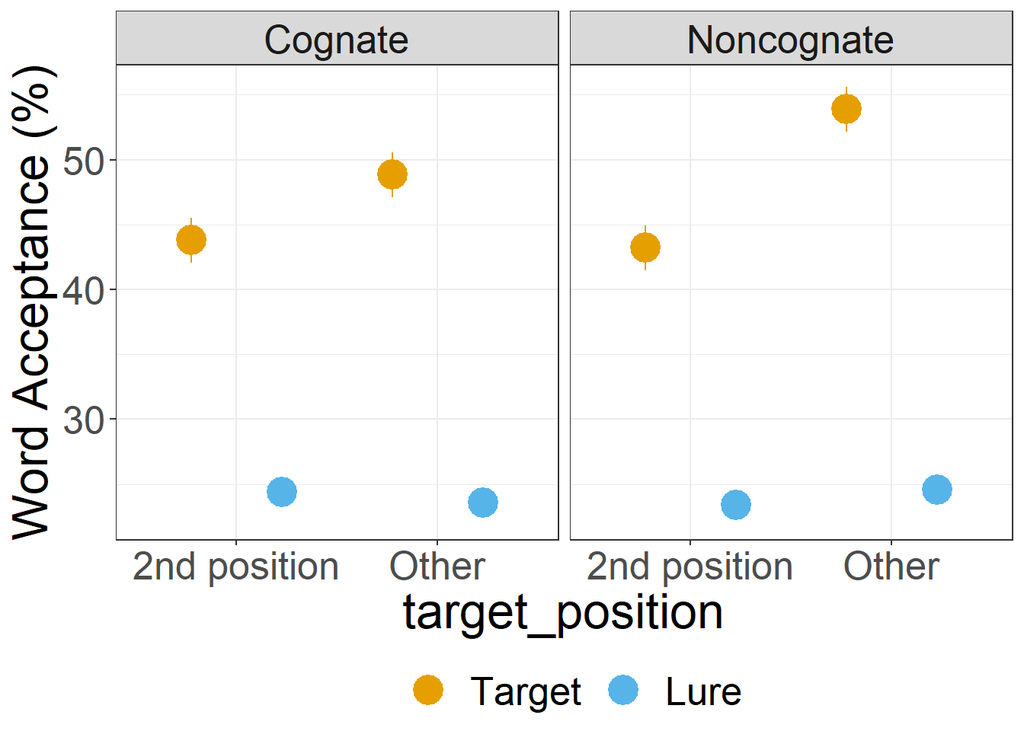

### Word Length (monosyllabic, bisyllabic)

```
## Generalized linear mixed model fit by maximum likelihood (Laplace
##   Approximation) [glmerMod]
##  Family: binomial  ( logit )
## Formula: detection ~ 1 + Utterance_Type * Word_Status * Syllable + (1 |
##     subject_nr) + (1 | Sentence_Num)
##    Data: Lseg_Htest
## Control: glmerControl(optimizer = "bobyqa")
##
##      AIC      BIC   logLik deviance df.resid
##  10450.1  10522.2  -5215.1  10430.1     9946
##
## Scaled residuals:
##     Min      1Q  Median      3Q     Max
## -2.8028 -0.6113 -0.3456  0.7564  7.0571
##
## Random effects:
##  Groups       Name        Variance Std.Dev.
##  Sentence_Num (Intercept) 0.05814  0.2411
##  subject_nr   (Intercept) 1.46376  1.2099
## Number of obs: 9956, groups:  Sentence_Num, 160; subject_nr, 88
##
## Fixed effects:
##                                        Estimate Std. Error z value Pr(>|z|)
## (Intercept)                            -0.78912    0.13345  -5.913 3.36e-09 ***
## Utterance_Type1                        -0.05315    0.04992  -1.065   0.2870
## Word_Status1                            1.27735    0.05104  25.027  < 2e-16 ***
## Syllable1                              -0.13591    0.06284  -2.163   0.0306 *
## Utterance_Type1:Word_Status1           -0.10298    0.09989  -1.031   0.3026
## Utterance_Type1:Syllable1              -0.09908    0.09982  -0.993   0.3209
## Word_Status1:Syllable1                 -0.16465    0.09997  -1.647   0.0996 .
## Utterance_Type1:Word_Status1:Syllable1  0.19795    0.19976   0.991   0.3217
## ---
## Signif. codes:  0 '***' 0.001 '**' 0.01 '*' 0.05 '.' 0.1 ' ' 1
##
## Correlation of Fixed Effects:
##             (Intr) Utt_T1 Wrd_S1 Syllb1 Ut_T1:W_S1 U_T1:S W_S1:S
## Uttrnc_Typ1  0.001
## Word_Stats1  0.028 -0.002
## Syllable1    0.003  0.006 -0.007
## Utt_T1:W_S1  0.001  0.219 -0.002 -0.007
## Uttrn_T1:S1  0.002  0.006 -0.010 -0.001 -0.004
## Wrd_Stt1:S1  0.001 -0.009  0.002  0.174  0.007      0.001
## U_T1:W_S1:S -0.002 -0.004  0.008  0.000  0.006      0.219 -0.001
```

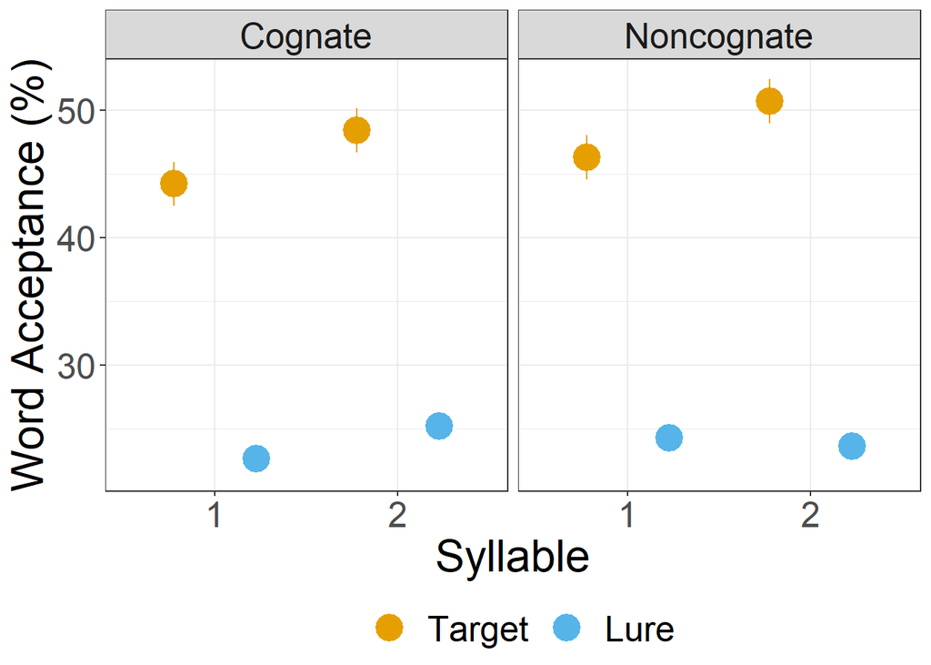

### ALINE Score

skipping ALINE score analysis for now, need to check stimuli file

Ultimately, will want to calculate based on ALINE value of cognate/noncognate in the sentence.

## Participant Variables: Predictors

### Correlation Individual Differences

Take with a grain of salt, these scores are the “grob” ones coded during the experiment and for some participants there are missing values (for unsure codes), but this should be fairly close to what the final coded values will be.

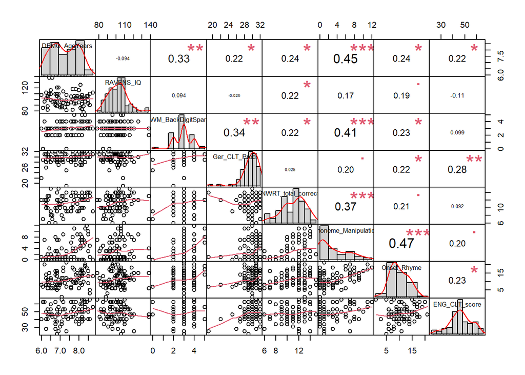

### Phonological Awareness

#### Phoneme Manipulation task score

```
## Generalized linear mixed model fit by maximum likelihood (Laplace
##   Approximation) [glmerMod]
##  Family: binomial  ( logit )
## Formula:
## detection ~ 1 + Utterance_Type * Word_Status * Phoneme_Manipulation.c +
##     (1 | subject_nr) + (1 | Sentence_Num)
##    Data: Lseg_Htest
## Control: glmerControl(optimizer = "bobyqa")
##
##      AIC      BIC   logLik deviance df.resid
##  10311.7  10383.7  -5145.9  10291.7     9830
##
## Scaled residuals:
##     Min      1Q  Median      3Q     Max
## -2.8839 -0.6179 -0.3378  0.7657  6.6637
##
## Random effects:
##  Groups       Name        Variance Std.Dev.
##  Sentence_Num (Intercept) 0.06148  0.2479
##  subject_nr   (Intercept) 1.42727  1.1947
## Number of obs: 9840, groups:  Sentence_Num, 160; subject_nr, 87
##
## Fixed effects:
##                                                      Estimate Std. Error
## (Intercept)                                         -0.782367   0.132728
## Utterance_Type1                                     -0.052341   0.050333
## Word_Status1                                         1.266811   0.051385
## Phoneme_Manipulation.c                               0.001494   0.039231
## Utterance_Type1:Word_Status1                        -0.118274   0.100698
## Utterance_Type1:Phoneme_Manipulation.c               0.013051   0.014939
## Word_Status1:Phoneme_Manipulation.c                  0.119064   0.015259
## Utterance_Type1:Word_Status1:Phoneme_Manipulation.c -0.058931   0.029862
##                                                     z value Pr(>|z|)
## (Intercept)                                          -5.895 3.76e-09 ***
## Utterance_Type1                                      -1.040   0.2984
## Word_Status1                                         24.653  < 2e-16 ***
## Phoneme_Manipulation.c                                0.038   0.9696
## Utterance_Type1:Word_Status1                         -1.175   0.2402
## Utterance_Type1:Phoneme_Manipulation.c                0.874   0.3823
## Word_Status1:Phoneme_Manipulation.c                   7.803 6.04e-15 ***
## Utterance_Type1:Word_Status1:Phoneme_Manipulation.c  -1.973   0.0484 *
## ---
## Signif. codes:  0 '***' 0.001 '**' 0.01 '*' 0.05 '.' 0.1 ' ' 1
##
## Correlation of Fixed Effects:
##             (Intr) Utt_T1 Wrd_S1 Phn_M. Ut_T1:W_S1 U_T1:P W_S1:P
## Uttrnc_Typ1  0.000
## Word_Stats1  0.029  0.002
## Phnm_Mnplt.  0.000 -0.004 -0.011
## Utt_T1:W_S1  0.001  0.215 -0.008  0.002
## Utt_T1:P_M. -0.004 -0.002  0.009 -0.006 -0.057
## Wrd_S1:P_M. -0.011  0.009  0.007  0.028 -0.020      0.007
## U_T1:W_S1:P  0.002 -0.059 -0.020  0.002 -0.002      0.180 -0.033
```

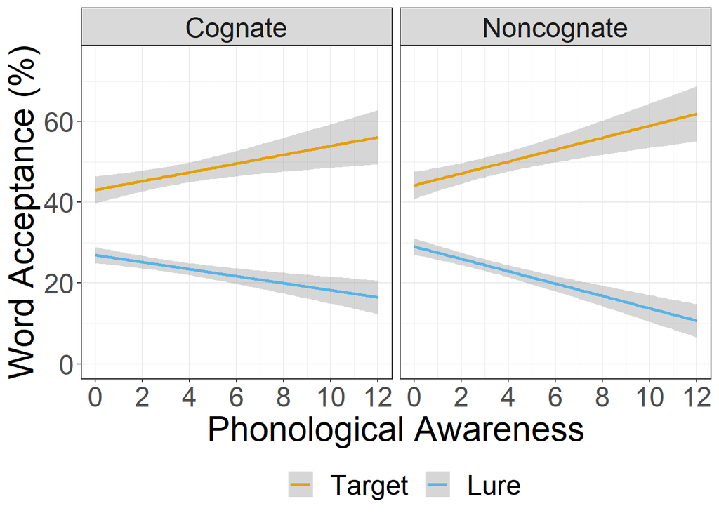

#### Onset/Rhyme Score

```
## Generalized linear mixed model fit by maximum likelihood (Laplace
##   Approximation) [glmerMod]
##  Family: binomial  ( logit )
## Formula: detection ~ 1 + Utterance_Type * Word_Status * Onset_Rhyme.c +
##     (1 | subject_nr) + (1 | Sentence_Num)
##    Data: Lseg_Htest
## Control: glmerControl(optimizer = "bobyqa")
##
##      AIC      BIC   logLik deviance df.resid
##  10182.2  10254.1  -5081.1  10162.2     9717
##
## Scaled residuals:
##     Min      1Q  Median      3Q     Max
## -2.7524 -0.6092 -0.3282  0.7495  7.7074
##
## Random effects:
##  Groups       Name        Variance Std.Dev.
##  Sentence_Num (Intercept) 0.06146  0.2479
##  subject_nr   (Intercept) 1.43381  1.1974
## Number of obs: 9727, groups:  Sentence_Num, 160; subject_nr, 86
##
## Fixed effects:
##                                             Estimate Std. Error z value
## (Intercept)                                -0.791002   0.133800  -5.912
## Utterance_Type1                            -0.039819   0.050738  -0.785
## Word_Status1                                1.255987   0.051717  24.286
## Onset_Rhyme.c                              -0.031116   0.031157  -0.999
## Utterance_Type1:Word_Status1               -0.103405   0.101498  -1.019
## Utterance_Type1:Onset_Rhyme.c               0.009517   0.012032   0.791
## Word_Status1:Onset_Rhyme.c                  0.109916   0.012255   8.969
## Utterance_Type1:Word_Status1:Onset_Rhyme.c -0.058023   0.024041  -2.413
##                                            Pr(>|z|)
## (Intercept)                                3.38e-09 ***
## Utterance_Type1                              0.4326
## Word_Status1                                < 2e-16 ***
## Onset_Rhyme.c                                0.3179
## Utterance_Type1:Word_Status1                 0.3083
## Utterance_Type1:Onset_Rhyme.c                0.4290
## Word_Status1:Onset_Rhyme.c                  < 2e-16 ***
## Utterance_Type1:Word_Status1:Onset_Rhyme.c   0.0158 *
## ---
## Signif. codes:  0 '***' 0.001 '**' 0.01 '*' 0.05 '.' 0.1 ' ' 1
##
## Correlation of Fixed Effects:
##             (Intr) Utt_T1 Wrd_S1 Ons_R. Ut_T1:W_S1 U_T1:O W_S1:O
## Uttrnc_Typ1 -0.001
## Word_Stats1  0.028  0.003
## Onst_Rhym.c  0.008 -0.003 -0.018
## Utt_T1:W_S1  0.002  0.211 -0.011  0.002
## Utt_T1:O_R. -0.003  0.027  0.008 -0.004 -0.069
## Wrd_S1:O_R. -0.018  0.009  0.034  0.023 -0.018      0.008
## U_T1:W_S1:O  0.003 -0.071 -0.018  0.002  0.026      0.170 -0.022
```

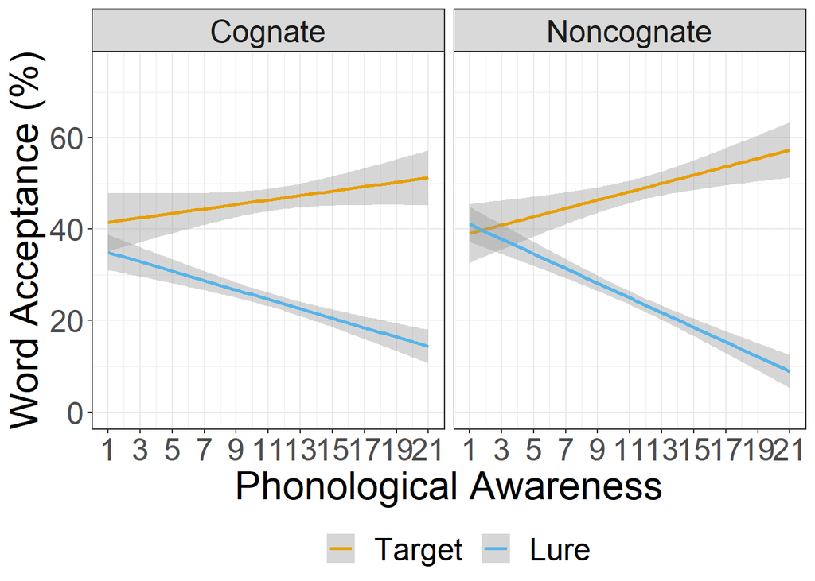

### Grade

Approximation for now for L1 knowledge

```
## Generalized linear mixed model fit by maximum likelihood (Laplace
##   Approximation) [glmerMod]
##  Family: binomial  ( logit )
## Formula: detection ~ 1 + Word_Type * Utterance_Type * DEMO_SchoolGrade +
##     (1 | subject_nr) + (1 | Sentence_Num)
##    Data: Lseg_Htest
## Control: glmerControl(optimizer = "bobyqa")
##
##      AIC      BIC   logLik deviance df.resid
##  10374.4  10475.3  -5173.2  10346.4     9942
##
## Scaled residuals:
##     Min      1Q  Median      3Q     Max
## -2.4078 -0.5977 -0.3447  0.7680  6.4081
##
## Random effects:
##  Groups       Name        Variance Std.Dev.
##  Sentence_Num (Intercept) 0.06332  0.2516
##  subject_nr   (Intercept) 1.42019  1.1917
## Number of obs: 9956, groups:  Sentence_Num, 160; subject_nr, 88
##
## Fixed effects:
##                                                                     Estimate
## (Intercept)                                                         -1.19126
## Word_TypeFollowing                                                   0.86151
## Word_TypeNoncognate                                                  0.04782
## Utterance_Type1                                                     -0.19857
## DEMO_SchoolGrade2nd grade/class                                     -0.57900
## Word_TypeFollowing:Utterance_Type1                                   0.19438
## Word_TypeNoncognate:Utterance_Type1                                  0.25198
## Word_TypeFollowing:DEMO_SchoolGrade2nd grade/class                   0.93017
## Word_TypeNoncognate:DEMO_SchoolGrade2nd grade/class                 -0.01760
## Utterance_Type1:DEMO_SchoolGrade2nd grade/class                      0.43754
## Word_TypeFollowing:Utterance_Type1:DEMO_SchoolGrade2nd grade/class  -0.63998
## Word_TypeNoncognate:Utterance_Type1:DEMO_SchoolGrade2nd grade/class -0.52749
##                                                                     Std. Error
## (Intercept)                                                            0.18419
## Word_TypeFollowing                                                     0.08028
## Word_TypeNoncognate                                                    0.08215
## Utterance_Type1                                                        0.11611
```

[output cut: 60 more lines]

```
## U_T1:DEMO_g -0.005  0.010  0.008 -0.640 -0.008  0.467  0.454  0.019   0.018
## W_TF:U_T1:g  0.004 -0.008 -0.006  0.488  0.007 -0.667 -0.346 -0.017  -0.014
## W_TN:U_T1:g  0.004 -0.008 -0.003  0.455  0.006 -0.332 -0.644 -0.013  -0.013
##             U_T1:g W_TF:Ug
## Wrd_TypFllw
## Wrd_TypNncg
## Uttrnc_Typ1
## DEMO_ScG2g/
## Wrd_TF:U_T1
## Wrd_TN:U_T1
## W_TF:DEMO_g
## W_TN:DEMO_g
## U_T1:DEMO_g
## W_TF:U_T1:g -0.760
## W_TN:U_T1:g -0.710  0.540
```

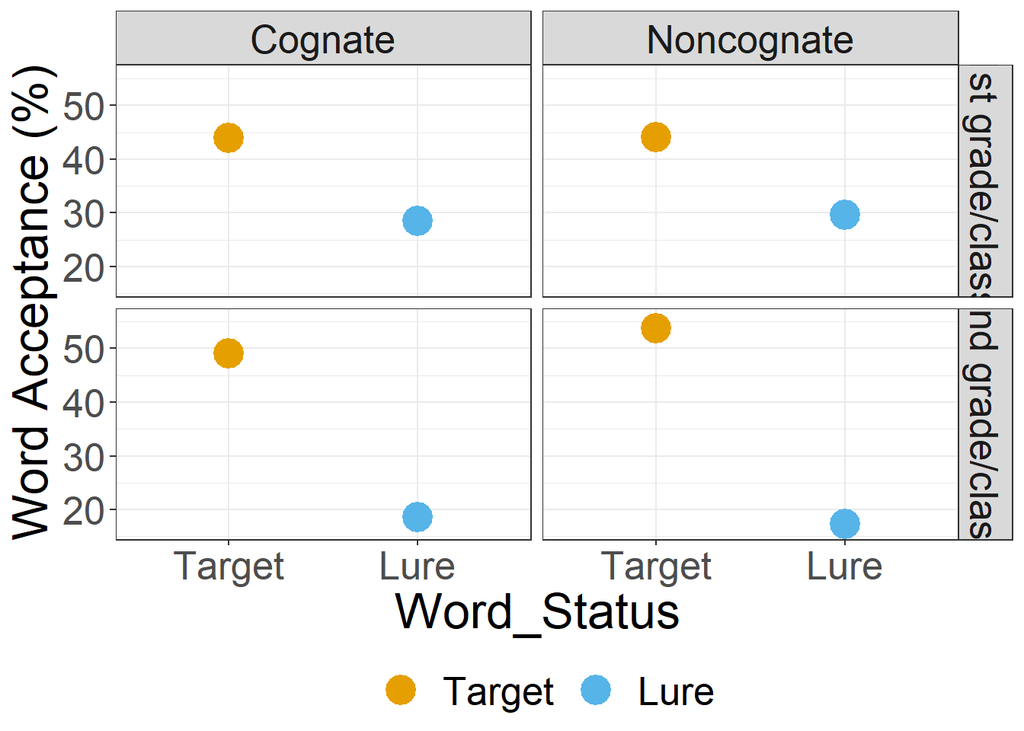